# Rapport test d’étude de survie INRIA

Naila Bouterfa

17/02/2021

```r
rm(list=ls())
```

Chargeons dans un premier temps les librairies utilisées ainsi que les données :

Librairies :

```r
library(stringr)
library(tidyverse)
library(tidyr)
library(dplyr)
library(ggplot2)
library(kableExtra)
library(gridExtra)
library(grid)
```

Importation des données :

```r
SurvivalData=read.delim(file="C:/Users/Naila/Desktop/brca_tcga_clinical.tsv")

# necessaire pour la dernière version de R car la conversion des chaines de caractère en facteur n'est plus faite automatiquement

for (i in 1:dim(SurvivalData)[2]){
if (class(SurvivalData[,i])=="character"){
  SurvivalData[,i]=as.factor(SurvivalData[,i])}
}

# verification
# lapply(SurvivalData,class)
```

Dimensions du dataset :

```r
dim(SurvivalData)
```

```
## [1] 2164  154
```

Nous avons ainsi 2164 lignes et 154 colonnes/variables

## Nettoyage des données

Il semblerait qu’il y ait pas mal de données manquantes voyons pour une première variables.

```r
# Ex :

length(levels(SurvivalData$case_id))
```

```
## [1] 1082
```

```r
which(is.na(SurvivalData$case_id)==TRUE)
```

```
## integer(0)
```

```r
which(SurvivalData$case_id=="'--")
```

```
## integer(0)
```

Le nombre de patients soit 1082 patients et ne correspond pas au nombre de ligne en fait il s’agit de la moitié du nombre de lignes, il y a deux ligne pour chaque patient. Il faut vérifier qu’il ne s’agit pas de doublons.

D’un autre coté il n’y a pas de données manquantes pour cette variable.

On va vérifier ces mêmes informations pour toutes les autres variables de la manière qui suit :

```r
SDvalues=c()
for (i in 1:154){
  SDvalues[i]=length(levels(SurvivalData[,i]))
  names(SDvalues)[i]=colnames(SurvivalData)[i]
}
head(SDvalues)
```

```
##           case_id case_submitter_id        project_id      age_at_index
##              1082              1082                 1                 0
## age_is_obfuscated    cause_of_death
##                 1                 1
```

Les résultats obtenus diffèrent selon la classe de la variable, en effet :

```r
classSD=lapply(SurvivalData,class)
which(classSD!="factor")
```

```
##      age_at_index days_to_diagnosis
##                 4                47
```

On a des 0 pour la classe *integer* representée par les deux variables ci dessus, les autres variables étant de la classe *factor*

On a des 1 pour les variables de type *factor* qui ont pour champs une valeur identique. On peut le voir ci dessous :

```r
kable(head(SurvivalData[,names(which(SDvalues==1))])) %>%
  kable_styling(font_size = 9)%>%
  kableExtra::scroll_box(width = "100%", height = "300px")
```

| project_id | age_is_obfuscated | cause_of_death | cause_of_death_source | country_of_residence_at_enrollment | occupation_duration_years | premature_at_birth | weeks_gestation_at_birth | ajcc_clinical_m | ajcc_clinical_n | ajcc_clinical_stage | ajcc_clinical_t | anaplasia_present | anaplasia_present_type | ann_arbor_b_symptoms | ann_arbor_clinical_stage | ann_arbor_extranodal_involvement | ann_arbor_pathologic_stage | best_overall_response | breslow_thickness | burkitt_lymphoma_clinical_variant | child_pugh_classification | circumferential_resection_margin | classification_of_tumor | cog_liver_stage | cog_neuroblastoma_risk_group | cog_renal_stage | cog_rhabdomyosarcoma_risk_group | days_to_best_overall_response | days_to_last_known_disease_status | … |
| --- | --- | --- | --- | --- | --- | --- | --- | --- | --- | --- | --- | --- | --- | --- | --- | --- | --- | --- | --- | --- | --- | --- | --- | --- | --- | --- | --- | --- | --- | --- |
| TCGA-BRCA | ’– | ’– | ’– | ’– | ’– | ’– | ’– | ’– | ’– | ’– | ’– | ’– | ’– | ’– | ’– | ’– | ’– | ’– | ’– | ’– | ’– | ’– | not reported | ’– | ’– | ’– | ’– | ’– | ’– | … |
| TCGA-BRCA | ’– | ’– | ’– | ’– | ’– | ’– | ’– | ’– | ’– | ’– | ’– | ’– | ’– | ’– | ’– | ’– | ’– | ’– | ’– | ’– | ’– | ’– | not reported | ’– | ’– | ’– | ’– | ’– | ’– | … |
| TCGA-BRCA | ’– | ’– | ’– | ’– | ’– | ’– | ’– | ’– | ’– | ’– | ’– | ’– | ’– | ’– | ’– | ’– | ’– | ’– | ’– | ’– | ’– | ’– | not reported | ’– | ’– | ’– | ’– | ’– | ’– | … |
| TCGA-BRCA | ’– | ’– | ’– | ’– | ’– | ’– | ’– | ’– | ’– | ’– | ’– | ’– | ’– | ’– | ’– | ’– | ’– | ’– | ’– | ’– | ’– | ’– | not reported | ’– | ’– | ’– | ’– | ’– | ’– | … |
| TCGA-BRCA | ’– | ’– | ’– | ’– | ’– | ’– | ’– | ’– | ’– | ’– | ’– | ’– | ’– | ’– | ’– | ’– | ’– | ’– | ’– | ’– | ’– | ’– | not reported | ’– | ’– | ’– | ’– | ’– | ’– | … |
| TCGA-BRCA | ’– | ’– | ’– | ’– | ’– | ’– | ’– | ’– | ’– | ’– | ’– | ’– | ’– | ’– | ’– | ’– | ’– | ’– | ’– | ’– | ’– | ’– | not reported | ’– | ’– | ’– | ’– | ’– | ’– | … |

On va vouloir exclure les variables de classe factor dont les champs sont identiques pour chaque observation et non celles de la classe integer car elles n’apportent aucune information utile a notre dataset.

```r
names(which(SDvalues!=1))
```

```
##  [1] "case_id"                     "case_submitter_id"
##  [3] "age_at_index"                "days_to_birth"
##  [5] "days_to_death"               "ethnicity"
##  [7] "gender"                      "race"
##  [9] "vital_status"                "year_of_birth"
## [11] "year_of_death"               "age_at_diagnosis"
## [13] "ajcc_pathologic_m"           "ajcc_pathologic_n"
## [15] "ajcc_pathologic_stage"       "ajcc_pathologic_t"
## [17] "ajcc_staging_system_edition" "days_to_diagnosis"
## [19] "days_to_last_follow_up"      "icd_10_code"
## [21] "morphology"                  "primary_diagnosis"
## [23] "prior_malignancy"            "prior_treatment"
## [25] "site_of_resection_or_biopsy" "synchronous_malignancy"
## [27] "tissue_or_organ_of_origin"   "tumor_stage"
## [29] "year_of_diagnosis"           "treatment_or_therapy"
## [31] "treatment_type"
```

On créee le nouveau dataframe contenant simplement 31 variables au lieu de 154 toutes informatives.

```r
SData=SurvivalData[,names(which(SDvalues!=1))]
```

On remplace les valeurs manquante representées par la syntaxe ’– par NA

```r
SData[SData=="'--"]=NA
```

Vérifions la présence de doublons.

```r
#cat(colnames(SData))

# lignes

dim(SData%>%distinct(case_id,case_submitter_id,age_at_index,days_to_birth,days_to_death,ethnicity,gender,race,vital_status,year_of_birth,year_of_death,age_at_diagnosis,ajcc_pathologic_m,ajcc_pathologic_n,ajcc_pathologic_stage,ajcc_pathologic_t,ajcc_staging_system_edition,days_to_diagnosis,days_to_last_follow_up,icd_10_code,morphology,primary_diagnosis,prior_malignancy,prior_treatment,site_of_resection_or_biopsy,synchronous_malignancy,tissue_or_organ_of_origin,tumor_stage,year_of_diagnosis,treatment_or_therapy,treatment_type))
```

```
## [1] 2164   31
```

```r
# colonnes
setequal(SData$site_of_resection_or_biopsy,SData$tissue_or_organ_of_origin)
```

```
## [1] TRUE
```

```r
SData=SData[,-which(colnames(SData)=="site_of_resection_or_biopsy")]
```

Il n’y a pas de doublons. Le nombre de ligne est le même que celui de la table initiale cela signifie qu’au moins une variable diffère en terme de champs pour un même individu.

D’autre part, “days_to_diagnosis” bien que numérique contient une seule valeur “0” et peut être considérée également comme non informative

```r
summary(SData$days_to_diagnosis)
```

```
##    Min. 1st Qu.  Median    Mean 3rd Qu.    Max.
##       0       0       0       0       0       0
```

```r
SData=SData[,-which(colnames(SData)=="days_to_diagnosis")]
```

Les variables treatment_therapy et treatment_type sont liée, les champs de treatment_type devraient être des variable auquels la réponse est contenue dans treatment_therapy on peut les combiner en procédant comme ceci :

```r
SData=SData%>% pivot_wider(names_from = treatment_type, values_from = treatment_or_therapy)
colnames(SData)[28]="radiation_therapy"
colnames(SData)[29]="pharmaceutical_therapy"
```

Transformons les variables ci dessous de tel sorte que l’on attribue à “Yes” : 1 “No” : 0 “Not reported” : NA

```r
levels(SData$prior_malignancy)  = c(0,NA,1)
levels(SData$synchronous_malignancy)    = c(0,NA)
levels(SData$prior_treatment)   = c(0,NA,1)

levels(SData$radiation_therapy)     = c(0,NA,1)
levels(SData$pharmaceutical_therapy)    = c(0,NA,1)
```

```r
levels(SData$race)= c("american indian or alaska native", "asian", "black or african american",NA,"white")

levels(SData$tumor_stage)=c(NA, "stage i", "stage ia", "stage ib", "stage ii", "stage iia", "stage iib", "stage iii", "stage iiia", "stage iiib", "stage iiic", "stage iv", "stage x")
```

Nous pouvons créer une variable qui combine ces deux thérapies et nous renseigne sur la présence ou non de thérapie, on associe ainsi :

“Absence de thérapie” : 0 “Radiothérapie ou Therapie pharmaceutique” : 1 “Radiothérapie et Therapie pharmaceutique” : 2

```r
therapy=rep(NA,dim(SData)[1])

therapy=case_when(
  (SData$radiation_therapy==1 & SData$pharmaceutical_therapy==1) ~ 2,
  (SData$radiation_therapy==1 & SData$pharmaceutical_therapy==0) ~ 1,
  (SData$radiation_therapy==0 & SData$pharmaceutical_therapy==1) ~ 1,
  (SData$radiation_therapy==0 & SData$pharmaceutical_therapy==0) ~ 0)

therapy=as.factor(therapy)

SData=cbind(SData,therapy)
```

En résulte finalement le dataframe suivant :

```r
SData=as.data.frame(SData)

kable(head(SData)) %>%
  kable_styling(font_size = 9)%>%
  kableExtra::scroll_box(width = "100%", height = "300px")
```

| case_id | case_submitter_id | age_at_index | days_to_birth | days_to_death | ethnicity | gender | race | vital_status | year_of_birth | year_of_death | age_at_diagnosis | ajcc_pathologic_m | ajcc_pathologic_n | ajcc_pathologic_stage | ajcc_pathologic_t | ajcc_staging_system_edition | days_to_last_follow_up | icd_10_code | morphology | primary_diagnosis | prior_malignancy | prior_treatment | synchronous_malignancy | tissue_or_organ_of_origin | tumor_stage | year_of_diagnosis | radiation_therapy | pharmaceutical_therapy | therapy |
| --- | --- | --- | --- | --- | --- | --- | --- | --- | --- | --- | --- | --- | --- | --- | --- | --- | --- | --- | --- | --- | --- | --- | --- | --- | --- | --- | --- | --- | --- |
| 6956473b-92e5-4069-a26b-b48e280e76f2 | TCGA-B6-A0RU | 40 | -14920 | NA | not hispanic or latino | female | white | Alive | 1950 | NA | 14920 | M0 | N0 (i-) | Stage IA | T1c | 3rd | 8605.0 | C50.9 | 8523/3 | Infiltrating duct mixed with other types of carcinoma | 0 | 0 | 0 | Breast, NOS | stage ia | 1990 | 1 | 1 | 2 |
| 99927651-34be-4795-893a-128d8a1fdb30 | TCGA-AO-A12A | 47 | -17420 | NA | not hispanic or latino | female | white | Alive | 1956 | NA | 17420 | M0 | N0 (i+) | Stage IIA | T2 | 6th | 3112.0 | C50.9 | 8500/3 | Infiltrating duct carcinoma, NOS | 0 | 0 | 0 | Breast, NOS | stage iia | 2003 | 0 | 1 | 1 |
| 7d681cc6-689d-41c8-9e84-e13733089ec9 | TCGA-AR-A1AS | 54 | -20028 | NA | not reported | female | asian | Alive | 1953 | NA | 20028 | M0 | N1 | Stage IIB | T2 | 6th | 1150.0 | C50.9 | 8500/3 | Infiltrating duct carcinoma, NOS | 0 | 0 | 0 | Breast, NOS | stage iib | 2007 | 1 | 0 | 1 |
| 1cc30842-4a5b-4f07-b36f-5b84ceaa5662 | TCGA-BH-A8FZ | 58 | -21343 | NA | not hispanic or latino | female | white | Alive | 1954 | NA | 21343 | M0 | N0 | Stage IA | T1b | 7th | 574.0 | C50.9 | 8520/3 | Lobular carcinoma, NOS | 0 | 0 | 0 | Breast, NOS | stage ia | 2012 | 1 | 0 | 1 |
| 23c21dea-3713-408f-ba56-f7c586e9f206 | TCGA-E9-A1R5 | 63 | -23116 | NA | not hispanic or latino | female | white | Alive | 1948 | NA | 23116 | M0 | N0 | Stage IA | T1c | 7th | 92.0 | C50.9 | 8500/3 | Infiltrating duct carcinoma, NOS | 0 | 0 | 0 | Breast, NOS | stage ia | 2011 | 1 | 1 | 2 |
| a1872011-b928-4189-ac02-e87506c20bca | TCGA-A2-A0YC | 59 | -21685 | NA | not hispanic or latino | female | white | Alive | 1949 | NA | 21685 | M0 | N1mi | Stage IIB | T2 | NA | 990.0 | C50.9 | 8500/3 | Infiltrating duct carcinoma, NOS | 0 | 0 | 0 | Breast, NOS | stage iib | 2008 | 1 | 1 | 2 |

Nous avons dans celui ci 30 variables et 1082 lignes/patients

## Exploration des données

### Catégories et données manquantes

Pour toute variable nous pouvons voir dans le tableau ci dessous le nombre de catégories associés à la variable et la présence ou nom de valeurs manquantes :

```r
SD=matrix(NA,dim(SData)[2],3)

for (i in 1:dim(SData)[2]){
  SD[i,1]=colnames(SData)[i]
  SD[i,2]=length(levels(SData[,i]))
  SD[i,3]=length(which(is.na(SData[,i])))
}

colnames(SD)=c("Variables","Levels","NAs")
SD=as.data.frame(SD)
SD$NAs=as.numeric(as.character(SD$NAs))
SD$Levels=as.numeric(as.character(SD$Levels))

kable(SD)%>%kable_paper("hover", full_width = F,position = "left") %>%
  kable_styling(font_size = 12)%>%
  kableExtra::scroll_box(width = "100%", height = "300px")
```

| Variables | Levels | NAs |
| --- | --- | --- |
| case_id | 1082 | 0 |
| case_submitter_id | 1082 | 0 |
| age_at_index | 0 | 0 |
| days_to_birth | 1032 | 15 |
| days_to_death | 144 | 932 |
| ethnicity | 3 | 0 |
| gender | 2 | 0 |
| race | 4 | 95 |
| vital_status | 2 | 0 |
| year_of_birth | 74 | 3 |
| year_of_death | 21 | 979 |
| age_at_diagnosis | 1032 | 15 |
| ajcc_pathologic_m | 4 | 0 |
| ajcc_pathologic_n | 16 | 0 |
| ajcc_pathologic_stage | 13 | 11 |
| ajcc_pathologic_t | 12 | 0 |
| ajcc_staging_system_edition | 6 | 141 |
| days_to_last_follow_up | 753 | 103 |
| icd_10_code | 7 | 0 |
| morphology | 22 | 0 |
| primary_diagnosis | 22 | 0 |
| prior_malignancy | 2 | 1 |
| prior_treatment | 2 | 2 |
| synchronous_malignancy | 1 | 69 |
| tissue_or_organ_of_origin | 6 | 0 |
| tumor_stage | 12 | 11 |
| year_of_diagnosis | 27 | 2 |
| radiation_therapy | 2 | 94 |
| pharmaceutical_therapy | 2 | 102 |
| therapy | 3 | 103 |

## Analyse descriptive et visualisation

Variables catégorielles et effectifs:

Informations élémentaires sur les patients :

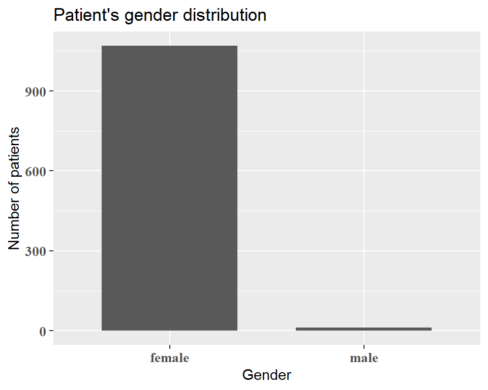

```r
ggplot(SData,aes(gender))+
  geom_bar(width = 0.7, position = position_dodge(width = 0.9))+
  theme(axis.text = element_text(family = "serif", size = 10, face = "bold"))+
  ggtitle("Patient's gender distribution") +
  xlab("Gender") + ylab("Number of patients")
```

```r
kable(table(SData$gender),col.names = c("Gender","Counts"),caption = "Gender")%>%
  kable_styling(font_size = 12)
```

Gender

| Gender | Counts |
| --- | --- |
| female | 1070 |
| male | 12 |

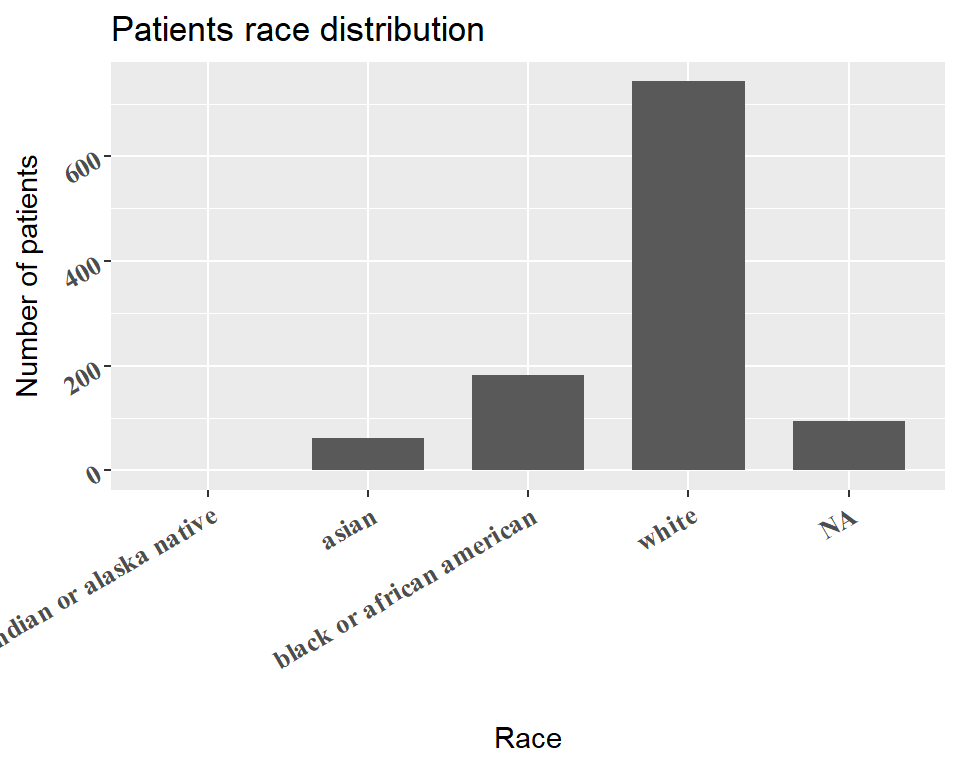

```r
ggplot(SData,aes(race))+
  geom_bar(width = 0.7, position = position_dodge(width = 0.9))+
  theme(axis.text = element_text(family = "serif", size = 10, face = "bold",angle = 30, hjust=1))+
  ggtitle("Patients race distribution") +
  xlab("Race") + ylab("Number of patients")
```

```r
kable(table(SData$race),col.names = c("Race","Counts"),caption = "Race")%>%
  kable_styling(font_size = 12)
```

Race

| Race | Counts |
| --- | --- |
| american indian or alaska native | 1 |
| asian | 61 |
| black or african american | 182 |
| white | 743 |

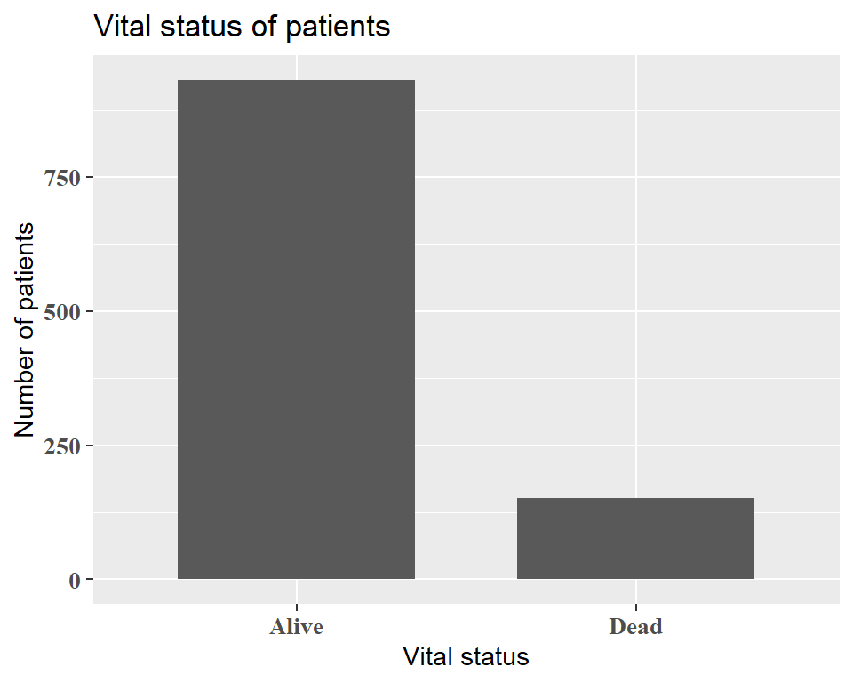

```r
ggplot(SData,aes(vital_status))+
  geom_bar(width = 0.7, position = position_dodge(width = 0.9))+
  theme(axis.text = element_text(family = "serif", size = 10, face = "bold"))+
  ggtitle("Vital status of patients") +
  xlab("Vital status") + ylab("Number of patients")
```

```r
kable(table(SData$vital_status),col.names = c("Vital status","Counts"),caption = "Vital status")%>%kable_styling(font_size = 12)
```

Vital status

| Vital status | Counts |
| --- | --- |
| Alive | 931 |
| Dead | 151 |

Historique des patient par rapport à la maladie et au traitement :

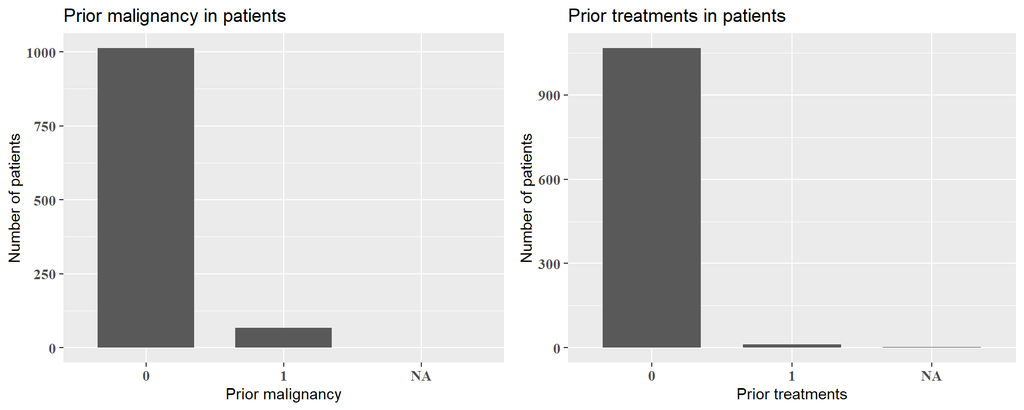

```r
grid.arrange(ggplot(SData,aes(prior_malignancy))+
  geom_bar(width = 0.7, position = position_dodge(width = 0.9))+
  theme(axis.text = element_text(family = "serif", size = 10, face = "bold"))+
  ggtitle("Prior malignancy in patients") +
  xlab("Prior malignancy") + ylab("Number of patients"),
ggplot(SData,aes(prior_treatment))+
  geom_bar(width = 0.7, position = position_dodge(width = 0.9))+
  theme(axis.text = element_text(family = "serif", size = 10, face = "bold"))+
  ggtitle("Prior treatments in patients") +
  xlab("Prior treatments") + ylab("Number of patients"),
ncol = 2,widths=c(4,4))
```

```r
kable(cbind(table(SData$prior_malignancy),table(SData$prior_treatment)),col.names = c("prior_malignancy","prior_treatment"),caption = "Retrospective situation of patients")%>%kable_styling(font_size = 12)
```

Retrospective situation of patients

|  | prior_malignancy | prior_treatment |
| --- | --- | --- |
| 0 | 1013 | 1067 |
| 1 | 68 | 13 |

Autres variables peu informatives :

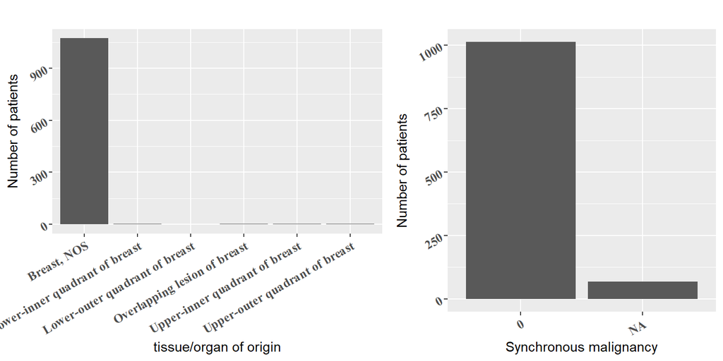

```r
grid.arrange(ggplot(SData,aes(tissue_or_organ_of_origin))+
  geom_bar()+
  theme(axis.text = element_text(family = "serif", size = 10, face = "bold",angle = 30, hjust=1))+
  ggtitle(" ") +
  xlab("tissue/organ of origin") + ylab("Number of patients"),
ggplot(SData,aes(synchronous_malignancy))+
  geom_bar()+
  theme(axis.text = element_text(family = "serif", size = 10, face = "bold",angle = 30, hjust=1))+
  ggtitle(" ") +
  xlab("Synchronous malignancy") + ylab("Number of patients"),ncol = 2,widths=c(7,6)
)
```

Stage de la tumeur :

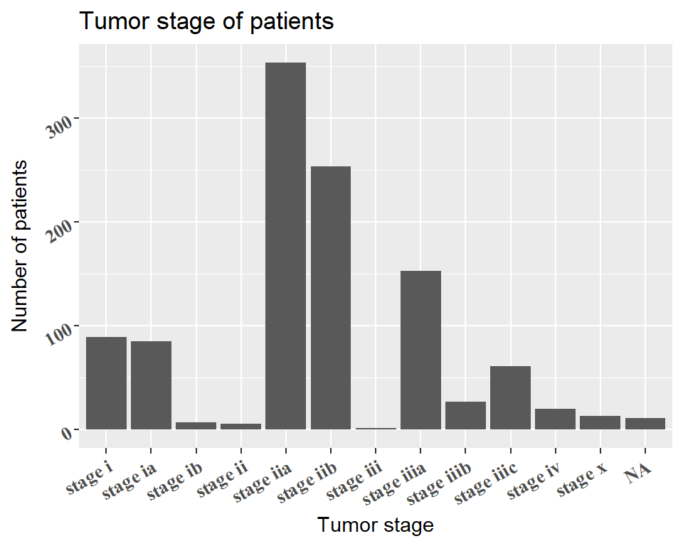

```r
ggplot(SData,aes(tumor_stage))+
  geom_bar()+
  theme(axis.text = element_text(family = "serif", size = 10, face = "bold",angle = 30, hjust=1))+
  ggtitle("Tumor stage of patients") +
  xlab("Tumor stage") + ylab("Number of patients")
```

```r
kable(table(SData$tumor_stage),col.names = c("Tumor stage","Counts"),caption = "Tumor stage")%>%kable_styling(font_size = 12)%>%
  kableExtra::scroll_box(width = "100%", height = "300px")
```

Tumor stage

| Tumor stage | Counts |
| --- | --- |
| stage i | 89 |
| stage ia | 85 |
| stage ib | 7 |
| stage ii | 6 |
| stage iia | 354 |
| stage iib | 254 |
| stage iii | 2 |
| stage iiia | 153 |
| stage iiib | 27 |
| stage iiic | 61 |
| stage iv | 20 |
| stage x | 13 |

Types de thérapies :

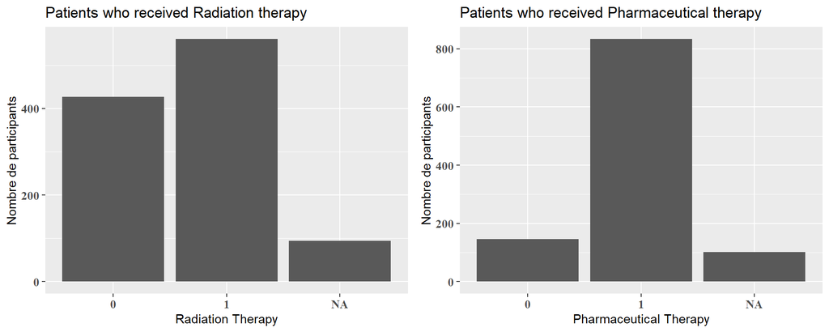

```r
grid.arrange(ggplot(SData,aes(radiation_therapy))+
  geom_bar()+
  theme(axis.text = element_text(family = "serif", size = 10, face = "bold"))+
  ggtitle("Patients who received Radiation therapy ") +
  xlab("Radiation Therapy") + ylab("Nombre de participants"),
ggplot(SData,aes(pharmaceutical_therapy))+
  geom_bar()+
  theme(axis.text = element_text(family = "serif", size = 10, face = "bold"))+
  ggtitle("Patients who received Pharmaceutical therapy ") +
  xlab("Pharmaceutical Therapy") + ylab("Nombre de participants"),ncol = 2,widths=c(4,4))
```

```r
kable(cbind(table(SData$radiation_therapy),table(SData$pharmaceutical_therapy)),col.names = c("Radiation Therapy","Pharmaceutical Therapy"),caption = "Type of treatment received")%>%kable_styling(font_size = 12)
```

Type of treatment received

|  | Radiation Therapy | Pharmaceutical Therapy |
| --- | --- | --- |
| 0 | 427 | 146 |
| 1 | 561 | 834 |

Variables ajcc :

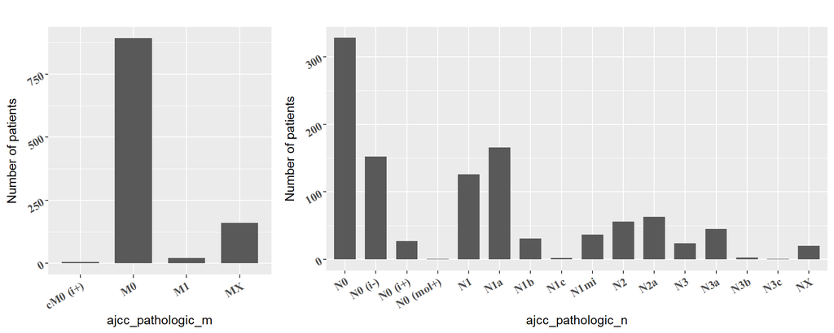

```r
grid.arrange(ggplot(SData,aes(ajcc_pathologic_m))+
  geom_bar(width = 0.7, position = position_dodge(width = 0.9))+
  theme(axis.text = element_text(family = "serif", size = 10, face = "bold",angle = 30, hjust=1))+
  ggtitle(" ") +
  xlab("ajcc_pathologic_m") + ylab("Number of patients"),
ggplot(SData,aes(ajcc_pathologic_n))+
  geom_bar(width = 0.7, position = position_dodge(width = 0.9))+
  theme(axis.text = element_text(family = "serif", size = 10, face = "bold",angle = 30, hjust=1))+
  ggtitle("") +
  xlab("ajcc_pathologic_n") + ylab("Number of patients"),
ncol = 2,widths=c(3,6))
```

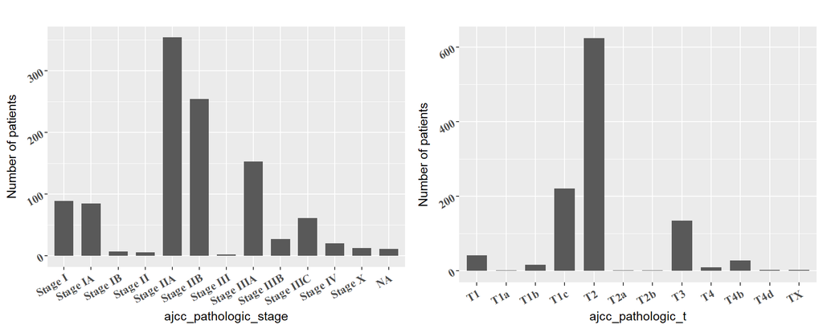

```r
grid.arrange(ggplot(SData,aes(ajcc_pathologic_stage))+
  geom_bar(width = 0.7, position = position_dodge(width = 0.9))+
  theme(axis.text = element_text(family = "serif", size = 10, face = "bold",angle = 30, hjust=1))+
  ggtitle("") +
  xlab("ajcc_pathologic_stage") + ylab("Number of patients"),
ggplot(SData,aes(ajcc_pathologic_t))+
  geom_bar(width = 0.7, position = position_dodge(width = 0.9))+
  theme(axis.text = element_text(family = "serif", size = 10, face = "bold",angle = 30, hjust=1))+
  ggtitle("") +
  xlab("ajcc_pathologic_t") + ylab("Number of patients"),
ncol = 2,widths=c(4,4))
```

Variable continue (age de diagnostique) :

```r
summary(SData$age_at_index)
```

```
##    Min. 1st Qu.  Median    Mean 3rd Qu.    Max.
##   26.00   49.00   58.00   58.48   67.00   90.00
```

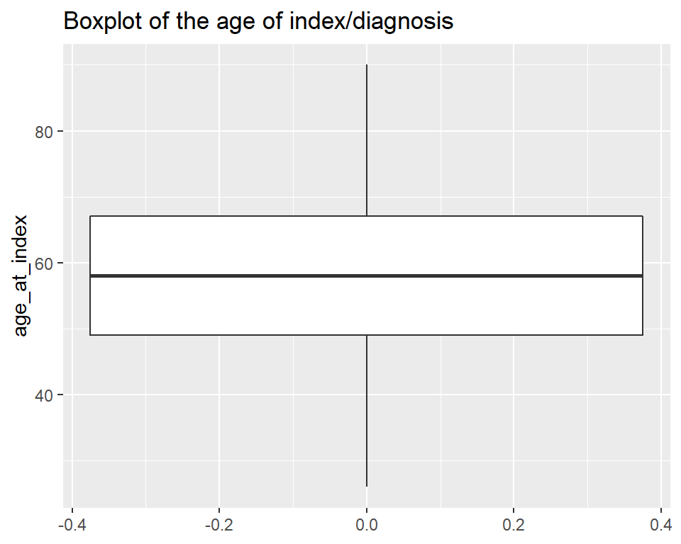

```r
ggplot(SData, aes(y = age_at_index)) + geom_boxplot()+
  ggtitle("Boxplot of the age of index/diagnosis")
```

# Analyse de survie

### Données relatives au temps :

Nous identifions les variables temporelles et dates que nous allons explorer.

```r
#"days_to_diagnosis" :  retiré car il ne s'agit pas d'une variable, elle ne varie justement pas et représente pour notre jeu de données la date de début de suivi ou d'étude

TimeSD=SData[,c("age_at_index","age_at_diagnosis","year_of_diagnosis","days_to_birth","year_of_birth","days_to_death","year_of_death","days_to_last_follow_up")]

kable(TimeSD) %>%
  kable_styling(font_size = 9)%>%
  kableExtra::scroll_box(width = "100%", height = "300px")
```

| age_at_index | age_at_diagnosis | year_of_diagnosis | days_to_birth | year_of_birth | days_to_death | year_of_death | days_to_last_follow_up |
| --- | --- | --- | --- | --- | --- | --- | --- |
| 40 | 14920 | 1990 | -14920 | 1950 | NA | NA | 8605.0 |
| 47 | 17420 | 2003 | -17420 | 1956 | NA | NA | 3112.0 |
| 54 | 20028 | 2007 | -20028 | 1953 | NA | NA | 1150.0 |
| 58 | 21343 | 2012 | -21343 | 1954 | NA | NA | 574.0 |
| 63 | 23116 | 2011 | -23116 | 1948 | NA | NA | 92.0 |
| 59 | 21685 | 2008 | -21685 | 1949 | NA | NA | 990.0 |
| 62 | 22779 | 2010 | -22779 | 1948 | NA | NA | 528.0 |
| 34 | 12601 | 2004 | -12601 | 1970 | NA | NA | 3204.0 |
| 72 | 26423 | 2011 | -26423 | 1939 | NA | NA | 724.0 |
| 90 | 32872 | 2012 | -32872 | 1922 | NA | NA | 0.0 |
| 68 | 24841 | 2011 | -24841 | 1943 | 322 | 2011 | NA |
| 82 | 30085 | 2006 | -30085 | 1924 | 1365 | 2009 | NA |
| 43 | 15996 | 2011 | -15996 | 1968 | NA | NA | 51.0 |
| 56 | 20694 | 2007 | -20694 | 1951 | NA | NA | 1528.0 |
| 73 | 26724 | 2008 | -26724 | 1935 | NA | NA | 1492.0 |
| 47 | 17529 | 2012 | -17529 | 1965 | NA | NA | 326.0 |
| 69 | 25362 | 2002 | -25362 | 1933 | 2483 | 2008 | NA |
| 52 | 19152 | 2006 | -19152 | 1954 | NA | NA | 1728.0 |
| 54 | 19723 | 2011 | -19723 | 1957 | NA | NA | 734.0 |
| 75 | 27627 | 2012 | -27627 | 1937 | NA | NA | 533.0 |
| 59 | 21857 | 2010 | -21857 | 1951 | NA | NA | 170.0 |
| 51 | 18991 | 2004 | -18991 | 1953 | NA | NA | 3807.0 |
| 62 | 22788 | 2011 | -22788 | 1949 | NA | NA | 647.0 |
| 54 | 20065 | 2008 | -20065 | 1954 | NA | NA | 1047.0 |
| 66 | 24439 | 2012 | -24439 | 1946 | NA | NA | 754.0 |
| 45 | 16658 | 2011 | -16658 | 1966 | NA | NA | 612.0 |
| 55 | 20173 | 2011 | -20173 | 1956 | NA | NA | 373.0 |
| 72 | 26484 | 2010 | -26484 | 1938 | NA | NA | 611.0 |
| 68 | 25186 | 2011 | -25186 | 1943 | NA | NA | 451.0 |
| 51 | 18694 | 2011 | -18694 | 1960 | NA | NA | 1001.0 |

[output cut: 1052 more lines]

*Days to birth* et *age at diagnosis* contiennent la même information symétrique :

```r
setequal(-as.numeric(as.character(SData$days_to_birth)),SData$age_at_diagnosis)
```

```
## [1] TRUE
```

De même *age at index* et *age at diagnosis* contiennent la même information l’une donnée en jours et l’autre en années

```r
#intersect(as.numeric(as.character(SData$age_at_index)),floor(as.numeric(as.character(SData$age_at_diagnosis))/365.25))

#as.numeric(as.character(SData$age_at_index))-floor(as.numeric(as.character(SData$age_at_diagnosis))/365.25)
```

Et en additionnant *year of birth* et *age at index* on obtient le même vecteur que *year of diagnosis*

```r
setequal(as.numeric(as.character(SData$year_of_birth))+as.numeric(as.character(SData$age_at_index)),SData$year_of_diagnosis)
```

```
## [1] TRUE
```

La variable *days to death* est renseignée pour les patients décédés et est comptabilisée à partir de l’index ou le diagnostique. On peut le voir entre autre pour le patient 11 :

```r
#which(TimeSD$days_to_death!="NA")
TimeSD[11,]
```

```
##    age_at_index age_at_diagnosis year_of_diagnosis days_to_birth year_of_birth
## 11           68            24841              2011        -24841          1943
##    days_to_death year_of_death days_to_last_follow_up
## 11           322          2011                   <NA>
```

En effet, on peut le vérifier en comparant le vecteur *year of death* au vecteur *years to death* additionné au *year at diagnosis*

```r
tmp=data.frame(cbind(as.numeric(as.character(SData$year_of_death)),as.numeric(as.character(SData$year_of_diagnosis))+floor(as.numeric(as.character(SData$days_to_death))/365.25)))%>%drop_na()

setequal(tmp[,1],tmp[,2])
```

```
## [1] TRUE
```

On peut considerer *days to last follow up* est disponible quand le patient est vivant :

```r
which(is.na(TimeSD$days_to_last_follow_up)==FALSE & is.na(TimeSD$year_of_death)==FALSE)
```

```
## integer(0)
```

```r
which(is.na(TimeSD$days_to_last_follow_up)==FALSE & is.na(TimeSD$days_to_death)==FALSE)
```

```
##  [1]   53  116  128  153  156  201  244  296  354  371  373  402  412  416  432
## [16]  433  446  447  448  461  463  468  484  488  552  597  602  605  681  743
## [31]  748  776  777  779  784  832  840  842  848  855  882  900  915  980 1035
## [46] 1036 1062
```

Ce n’est pas le cas pour la variable *days to death*. On trouve des patients pour lesquels les deux champs sont renseignés simultanemment.

Pour résumer les variables ;

- age_at_index, age_at_diagnosis et year_of_diagnosis font référence à la même chose dans deux unités de temps différentes d’un “age” communiqué au même temps qui est year_of diagnosis mais on pourrait aussi dire age at index ou year of index.
- La variable year_of_birth et days to birth se rapportent toutes deux à la naissance du patient days_to_birth est calculée par rapport à l’index. (les valeurs sont négatives car la naissance prédate le diagnostique)
- La variable year_of_death et days_to_death se rapportent toutes deux au décèd du patient (si il y a) days_to_death est également calculée par rapport à l’index.
- Enfin la variable days_to_follow_up est présente pour les patients vivants et sont a priori aussi calculées par rapport à l’index/diagnostique. (les valeurs sont postives car ces évenement ont lieu quant à eux post-diagnostique)

**Préparons les données à l’analyse de survie :**

Convertissons les variables ci-dessous en variables numériques :

```r
SData$days_to_death=as.numeric(as.character(SData$days_to_death))
SData$days_to_last_follow_up=as.numeric(as.character(SData$days_to_last_follow_up))
```

Convertissons la variable vital_status en variable catégorielle numérique :

```r
SData$vital_status=as.character(SData$vital_status)
SData$vital_status[which(SData$vital_status=="Alive")]=0
SData$vital_status[which(SData$vital_status=="Dead")]=1
SData$vital_status=as.numeric(SData$vital_status)

class(SData$vital_status)
```

```
## [1] "numeric"
```

Regardons les variables qui nous interessent de plus près :

```r
tmp=SData[,c("vital_status","year_of_death","days_to_death","days_to_last_follow_up")]

kable(head(tmp)) %>%
  kable_styling(font_size = 9)
```

| vital_status | year_of_death | days_to_death | days_to_last_follow_up |
| --- | --- | --- | --- |
| 0 | NA | NA | 8605 |
| 0 | NA | NA | 3112 |
| 0 | NA | NA | 1150 |
| 0 | NA | NA | 574 |
| 0 | NA | NA | 92 |
| 0 | NA | NA | 990 |

Pour définir notre objet de survie, il nous faudra deux variables :

Une première, temporelle, indiquant la durée à laquelle survient l’évènement étudié (ici le décès) pour ceux ayant vécu l’évènement et la durée d’observation pour ceux n’ayant pas vécu l’évènement (censure à droite).

Une seconde variable indiquant si les individus ont vécu l’évènement. Ici et conventionellement la variable survie est codée 1 pour les décès et 0 pour ceux ayant survécu.

```r
kable(head(tmp[which(is.na(tmp$days_to_last_follow_up)==FALSE & is.na(tmp$days_to_death)==FALSE),])) %>%
  kable_styling(font_size = 9)
```

|  | vital_status | year_of_death | days_to_death | days_to_last_follow_up |
| --- | --- | --- | --- | --- |
| 53 | 1 | NA | 821 | 515 |
| 116 | 1 | NA | 678 | 410 |
| 128 | 1 | NA | 1048 | 1038 |
| 153 | 1 | NA | 1034 | 1 |
| 156 | 1 | NA | 2636 | 2240 |
| 201 | 1 | NA | 1468 | 1468 |

Verifions si il existe des patients pour lesquels les valeurs de “days_to_last_follow_up” sont superieurs à “days_to_death”

```r
 which(tmp[which(is.na(TimeSD$days_to_last_follow_up)==FALSE & is.na(TimeSD$days_to_death)==FALSE),]$days_to_death<tmp[which(is.na(TimeSD$days_to_last_follow_up)==FALSE & is.na(TimeSD$days_to_death)==FALSE),]$days_to_last_follow_up)
```

```
## integer(0)
```

Corrigeons les données et créons la variable **time_fu** :

On va considerer que pour les individus ou les deux dates sont renseignées simultanemment avec days_to_death superieures a days_to_last_follow_up que les individus sont censurés donc vivants et leur affecter la valeur days_to_last_follow_up dans une nouvelle variable

```r
table(SData$vital_status)
```

```
##
##   0   1
## 931 151
```

```r
SData=SData%>%mutate(vital_status = if_else((vital_status == 1 & is.na(days_to_last_follow_up)== FALSE), 0, vital_status))

table(SData$vital_status)
```

```
##
##   0   1
## 979 103
```

```r
SData=SData%>%mutate(time_fu = if_else(vital_status == 1, days_to_death, days_to_last_follow_up))


class(SData$vital_status)
```

```
## [1] "numeric"
```

```r
# On peut egalement exclure des données les patients pour lesquels time_fu<0
SData=SData[-which(SData$time_fu<0),]


# Vérifions nos résultats pour notre liste d'individus

kable(head(SData[which(is.na(TimeSD$days_to_last_follow_up)==FALSE & is.na(TimeSD$days_to_death)==FALSE),c("vital_status","year_of_death","days_to_death","days_to_last_follow_up","time_fu")])) %>%
  kable_styling(font_size = 9)
```

|  | vital_status | year_of_death | days_to_death | days_to_last_follow_up | time_fu |
| --- | --- | --- | --- | --- | --- |
| 53 | 0 | NA | 821 | 515 | 515 |
| 116 | 0 | NA | 678 | 410 | 410 |
| 128 | 0 | NA | 1048 | 1038 | 1038 |
| 153 | 0 | NA | 1034 | 1 | 1 |
| 156 | 0 | NA | 2636 | 2240 | 2240 |
| 201 | 0 | NA | 1468 | 1468 | 1468 |

### Estimation de la survie

Importons les libraries propre à l’analyse de survie

```r
library(survival)
library(survminer)
```

```r
fit = survfit(formula = Surv(time_fu,vital_status) ~ 1, data = SData)
fit
```

```
## Call: survfit(formula = Surv(time_fu, vital_status) ~ 1, data = SData)
##
##       n  events  median 0.95LCL 0.95UCL
##    1081     103      NA    4267      NA
```

```r
d <- data.frame(time = fit$time,
                  n.risk = fit$n.risk,
                  n.event = fit$n.event,
                  n.censor = fit$n.censor,
                  surv = fit$surv,
                  upper = fit$upper,
                  lower = fit$lower
                  )



kable(d) %>%
  kable_styling(font_size = 9)%>%
  kableExtra::scroll_box(width = "100%", height = "300px")
```

| time | n.risk | n.event | n.censor | surv | upper | lower |
| --- | --- | --- | --- | --- | --- | --- |
| 0 | 1081 | 1 | 19 | 0.9990749 | 1.0000000 | 0.9972643 |
| 1 | 1061 | 1 | 3 | 0.9981333 | 1.0000000 | 0.9955519 |
| 2 | 1057 | 0 | 2 | 0.9981333 | 1.0000000 | 0.9955519 |
| 5 | 1055 | 0 | 3 | 0.9981333 | 1.0000000 | 0.9955519 |
| 7 | 1052 | 0 | 1 | 0.9981333 | 1.0000000 | 0.9955519 |
| 8 | 1051 | 0 | 1 | 0.9981333 | 1.0000000 | 0.9955519 |
| 9 | 1050 | 0 | 1 | 0.9981333 | 1.0000000 | 0.9955519 |
| 10 | 1049 | 0 | 15 | 0.9981333 | 1.0000000 | 0.9955519 |
| 11 | 1034 | 0 | 1 | 0.9981333 | 1.0000000 | 0.9955519 |
| 16 | 1033 | 0 | 1 | 0.9981333 | 1.0000000 | 0.9955519 |
| 17 | 1032 | 0 | 1 | 0.9981333 | 1.0000000 | 0.9955519 |
| 19 | 1031 | 0 | 1 | 0.9981333 | 1.0000000 | 0.9955519 |
| 21 | 1030 | 0 | 1 | 0.9981333 | 1.0000000 | 0.9955519 |
| 24 | 1029 | 0 | 1 | 0.9981333 | 1.0000000 | 0.9955519 |
| 26 | 1028 | 0 | 1 | 0.9981333 | 1.0000000 | 0.9955519 |
| 30 | 1027 | 1 | 5 | 0.9971614 | 1.0000000 | 0.9939583 |
| 31 | 1021 | 0 | 4 | 0.9971614 | 1.0000000 | 0.9939583 |
| 34 | 1017 | 0 | 2 | 0.9971614 | 1.0000000 | 0.9939583 |
| 40 | 1015 | 0 | 1 | 0.9971614 | 1.0000000 | 0.9939583 |
| 49 | 1014 | 0 | 1 | 0.9971614 | 1.0000000 | 0.9939583 |
| 51 | 1013 | 0 | 1 | 0.9971614 | 1.0000000 | 0.9939583 |
| 52 | 1012 | 0 | 1 | 0.9971614 | 1.0000000 | 0.9939583 |
| 54 | 1011 | 0 | 1 | 0.9971614 | 1.0000000 | 0.9939583 |
| 59 | 1010 | 0 | 1 | 0.9971614 | 1.0000000 | 0.9939583 |
| 64 | 1009 | 0 | 1 | 0.9971614 | 1.0000000 | 0.9939583 |
| 69 | 1008 | 0 | 1 | 0.9971614 | 1.0000000 | 0.9939583 |
| 70 | 1007 | 0 | 1 | 0.9971614 | 1.0000000 | 0.9939583 |
| 72 | 1006 | 0 | 1 | 0.9971614 | 1.0000000 | 0.9939583 |
| 76 | 1005 | 0 | 1 | 0.9971614 | 1.0000000 | 0.9939583 |
| 78 | 1004 | 0 | 3 | 0.9971614 | 1.0000000 | 0.9939583 |

[output cut: 789 more lines]

Considerons l’estimation de la survie a différents temps :

```r
summary(survfit(Surv(time_fu, vital_status) ~ 1, data = SData), times = 365.25)
```

```
## Call: survfit(formula = Surv(time_fu, vital_status) ~ 1, data = SData)
##
##  time n.risk n.event survival std.err lower 95% CI upper 95% CI
##   365    887      15    0.985 0.00394        0.977        0.992
```

La survie à 1 an du diagnostique est estimée à environ 98,5%

```r
summary(survfit(Surv(time_fu, vital_status) ~ 1, data = SData), times = 730.5)
```

```
## Call: survfit(formula = Surv(time_fu, vital_status) ~ 1, data = SData)
##
##  time n.risk n.event survival std.err lower 95% CI upper 95% CI
##   730    581      28    0.966 0.00633        0.954        0.979
```

La survie à 2 ans du diagnostique est estimée à environ 96,6%

La médiane (délai dans lequel la moitié des individus d’un échantillon sont décédés) n’est pas atteinte ici.

On peut cependant voir les valeurs associes a différent quantiles :

```r
tmp=survfit(Surv(time_fu, vital_status) ~ 1, data = SData)
quantile(tmp, 1:5/10)$quantile/365.25
```

```
##        10        20        30        40        50
##  4.495551  6.899384  9.475702 11.682409        NA
```

On en conclut que la survie est a priori plutot bonne.

Les chances que le patient pris au hasard d’être en vie avant le délai de 4 ans et demi du diagnostique est par exemple de 90%

### Courbe de Kaplan-Meier :

La courbe de survie permet de décrire le pourcentage de patients sans événement (encore en vie) au cours du temps. La méthode utilisée ici est la méthode de Kaplan Meier.

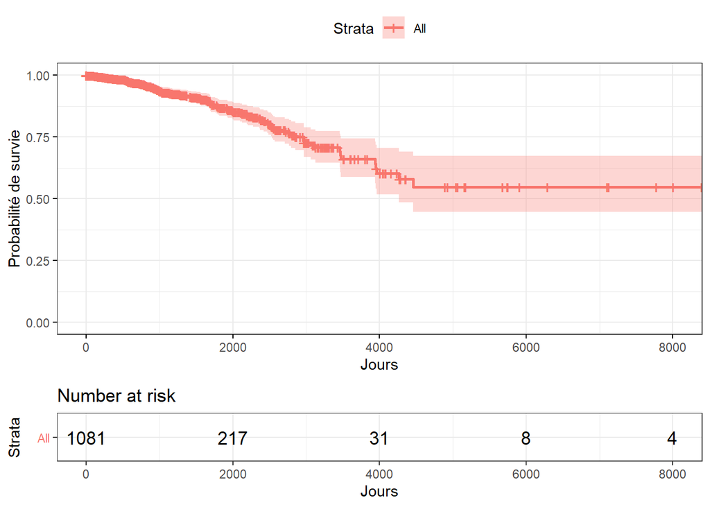

```r
ggsurvplot(fit, data = SData, pval = TRUE, risk.table = TRUE, surv.median.line = "hv",
           xlab="Jours",
           ylab="Probabilité de survie",
           ggtheme = theme_bw())
```

### Comparaison de la survie chez plusieurs groupes

#### Tests du Log rank

Les hypothèses du test : H0 : pas de différence de survie entre les deux groupes étudiés H1 : différence de survie entre les deux groupes étudiés

```r
survdiff(formula = Surv(time_fu,vital_status) ~ gender, data = SData)
```

```
## Call:
## survdiff(formula = Surv(time_fu, vital_status) ~ gender, data = SData)
##
##                  N Observed Expected (O-E)^2/E (O-E)^2/V
## gender=female 1069      103  102.155   0.00699     0.854
## gender=male     12        0    0.845   0.84485     0.854
##
##  Chisq= 0.9  on 1 degrees of freedom, p= 0.4
```

```r
survdiff(formula = Surv(time_fu,vital_status) ~ race, data = SData)
```

```
## Call:
## survdiff(formula = Surv(time_fu, vital_status) ~ race, data = SData)
##
## n=986, 95 observations deleted due to missingness.
##
##                                         N Observed Expected (O-E)^2/E (O-E)^2/V
## race=american indian or alaska native   1        0   0.0171  0.017068   0.01709
## race=asian                             61        1   2.9226  1.264801   1.31441
## race=black or african american        181       19  17.2235  0.183237   0.22261
## race=white                            743       78  77.8368  0.000342   0.00167
##
##  Chisq= 1.5  on 3 degrees of freedom, p= 0.7
```

```r
survdiff(formula = Surv(time_fu,vital_status) ~ radiation_therapy, data = SData)
```

```
## Call:
## survdiff(formula = Surv(time_fu, vital_status) ~ radiation_therapy,
##     data = SData)
##
## n=987, 94 observations deleted due to missingness.
##
##                       N Observed Expected (O-E)^2/E (O-E)^2/V
## radiation_therapy=0 426       36     23.7      6.43      10.3
## radiation_therapy=1 561       27     39.3      3.87      10.3
##
##  Chisq= 10.3  on 1 degrees of freedom, p= 0.001
```

```r
survdiff(formula = Surv(time_fu,vital_status) ~ pharmaceutical_therapy, data = SData)
```

```
## Call:
## survdiff(formula = Surv(time_fu, vital_status) ~ pharmaceutical_therapy,
##     data = SData)
##
## n=980, 101 observations deleted due to missingness.
##
##                            N Observed Expected (O-E)^2/E (O-E)^2/V
## pharmaceutical_therapy=0 146       12     5.19     8.936      9.87
## pharmaceutical_therapy=1 834       47    53.81     0.862      9.87
##
##  Chisq= 9.9  on 1 degrees of freedom, p= 0.002
```

```r
survdiff(formula = Surv(time_fu,vital_status) ~ prior_malignancy, data = SData)
```

```
## Call:
## survdiff(formula = Surv(time_fu, vital_status) ~ prior_malignancy,
##     data = SData)
##
## n=1080, 1 observation deleted due to missingness.
##
##                       N Observed Expected (O-E)^2/E (O-E)^2/V
## prior_malignancy=0 1012       96    98.61    0.0692      1.64
## prior_malignancy=1   68        7     4.39    1.5547      1.64
##
##  Chisq= 1.6  on 1 degrees of freedom, p= 0.2
```

```r
survdiff(formula = Surv(time_fu,vital_status) ~ prior_treatment, data = SData)
```

```
## Call:
## survdiff(formula = Surv(time_fu, vital_status) ~ prior_treatment,
##     data = SData)
##
## n=1079, 2 observations deleted due to missingness.
##
##                      N Observed Expected (O-E)^2/E (O-E)^2/V
## prior_treatment=0 1066      101  102.356     0.018      2.88
## prior_treatment=1   13        2    0.644     2.854      2.88
##
##  Chisq= 2.9  on 1 degrees of freedom, p= 0.09
```

```r
survdiff(formula = Surv(time_fu,vital_status) ~ tumor_stage, data = SData)
```

```
## Call:
## survdiff(formula = Surv(time_fu, vital_status) ~ tumor_stage,
##     data = SData)
##
## n=1070, 11 observations deleted due to missingness.
##
##                          N Observed Expected (O-E)^2/E (O-E)^2/V
## tumor_stage=stage i     89       11   13.543     0.477     0.556
## tumor_stage=stage ia    85        2    7.354     3.898     4.227
## tumor_stage=stage ib     7        0    0.667     0.667     0.673
## tumor_stage=stage ii     6        0    0.841     0.841     0.855
## tumor_stage=stage iia  354       24   30.791     1.498     2.161
## tumor_stage=stage iib  254       19   24.513     1.240     1.639
## tumor_stage=stage iii    2        1    0.117     6.663     6.679
## tumor_stage=stage iiia 153       18   14.369     0.918     1.073
## tumor_stage=stage iiib  26        5    2.306     3.146     3.275
## tumor_stage=stage iiic  61        5    2.871     1.578     1.645
## tumor_stage=stage iv    20        9    1.529    36.510    37.127
## tumor_stage=stage x     13        7    2.099    11.444    11.772
##
##  Chisq= 69  on 11 degrees of freedom, p= 2e-10
```

```r
survdiff(formula = Surv(time_fu,vital_status) ~ ajcc_pathologic_m, data = SData)
```

```
## Call:
## survdiff(formula = Surv(time_fu, vital_status) ~ ajcc_pathologic_m,
##     data = SData)
##
##                              N Observed Expected (O-E)^2/E (O-E)^2/V
## ajcc_pathologic_m=cM0 (i+)   6        0    0.292     0.292     0.293
## ajcc_pathologic_m=M0       892       86   90.768     0.250     2.132
## ajcc_pathologic_m=M1        22        9    2.313    19.332    19.833
## ajcc_pathologic_m=MX       161        8    9.627     0.275     0.308
##
##  Chisq= 20.2  on 3 degrees of freedom, p= 2e-04
```

```r
survdiff(formula = Surv(time_fu,vital_status) ~ ajcc_pathologic_n, data = SData)
```

```
## Call:
## survdiff(formula = Surv(time_fu, vital_status) ~ ajcc_pathologic_n,
##     data = SData)
##
##                               N Observed Expected (O-E)^2/E (O-E)^2/V
## ajcc_pathologic_n=N0        327       16  25.8518   3.75443   5.06245
## ajcc_pathologic_n=N0 (i-)   152       10  21.3610   6.04244   7.77560
## ajcc_pathologic_n=N0 (i+)    27        2   3.0434   0.35772   0.36930
## ajcc_pathologic_n=N0 (mol+)   1        0   0.0132   0.01323   0.01324
## ajcc_pathologic_n=N1        126        8  13.8805   2.49131   2.88745
## ajcc_pathologic_n=N1a       166        5  13.4050   5.26996   6.10500
## ajcc_pathologic_n=N1b        31       24   7.0218  41.05213  45.38143
## ajcc_pathologic_n=N1c         2        1   0.2897   1.74102   1.74825
## ajcc_pathologic_n=N1mi       37        3   2.8770   0.00526   0.00544
## ajcc_pathologic_n=N2         56        6   5.1692   0.13351   0.14093
## ajcc_pathologic_n=N2a        63        9   4.5151   4.45493   4.67963
## ajcc_pathologic_n=N3         24        4   1.7333   2.96428   3.02619
## ajcc_pathologic_n=N3a        45        3   1.9494   0.56622   0.58314
## ajcc_pathologic_n=N3b         3        2   0.0921  39.52410  39.60632
## ajcc_pathologic_n=N3c         1        1   0.0221  43.33297  43.38159
## ajcc_pathologic_n=NX         20        9   1.7753  29.40100  29.99127
##
##  Chisq= 182  on 15 degrees of freedom, p= <2e-16
```

```r
survdiff(formula = Surv(time_fu,vital_status) ~ ajcc_pathologic_stage, data = SData)
```

```
## Call:
## survdiff(formula = Surv(time_fu, vital_status) ~ ajcc_pathologic_stage,
##     data = SData)
##
## n=1070, 11 observations deleted due to missingness.
##
##                                    N Observed Expected (O-E)^2/E (O-E)^2/V
## ajcc_pathologic_stage=Stage I     89       11   13.543     0.477     0.556
## ajcc_pathologic_stage=Stage IA    85        2    7.354     3.898     4.227
## ajcc_pathologic_stage=Stage IB     7        0    0.667     0.667     0.673
## ajcc_pathologic_stage=Stage II     6        0    0.841     0.841     0.855
## ajcc_pathologic_stage=Stage IIA  354       24   30.791     1.498     2.161
## ajcc_pathologic_stage=Stage IIB  254       19   24.513     1.240     1.639
## ajcc_pathologic_stage=Stage III    2        1    0.117     6.663     6.679
## ajcc_pathologic_stage=Stage IIIA 153       18   14.369     0.918     1.073
## ajcc_pathologic_stage=Stage IIIB  26        5    2.306     3.146     3.275
## ajcc_pathologic_stage=Stage IIIC  61        5    2.871     1.578     1.645
## ajcc_pathologic_stage=Stage IV    20        9    1.529    36.510    37.127
## ajcc_pathologic_stage=Stage X     13        7    2.099    11.444    11.772
##
##  Chisq= 69  on 11 degrees of freedom, p= 2e-10
```

```r
survdiff(formula = Surv(time_fu,vital_status) ~ ajcc_pathologic_t, data = SData)
```

```
## Call:
## survdiff(formula = Surv(time_fu, vital_status) ~ ajcc_pathologic_t,
##     data = SData)
##
##                         N Observed Expected (O-E)^2/E (O-E)^2/V
## ajcc_pathologic_t=T1   41        7   7.4618    0.0286    0.0312
## ajcc_pathologic_t=T1a   1        1   0.0394   23.4199   23.4510
## ajcc_pathologic_t=T1b  16        0   1.3963    1.3963    1.4194
## ajcc_pathologic_t=T1c 221       18  21.1983    0.4826    0.6111
## ajcc_pathologic_t=T2  624       49  53.7902    0.4266    0.8974
## ajcc_pathologic_t=T2a   1        0   0.0132    0.0132    0.0132
## ajcc_pathologic_t=T2b   1        1   0.0767   11.1104   11.1306
## ajcc_pathologic_t=T3  134       16  14.4367    0.1693    0.1981
## ajcc_pathologic_t=T4    8        1   0.8298    0.0349    0.0355
## ajcc_pathologic_t=T4b  28        7   2.0522   11.9289   12.2407
## ajcc_pathologic_t=T4d   3        2   0.4080    6.2109    6.2547
## ajcc_pathologic_t=TX    3        1   1.2973    0.0681    0.0700
##
##  Chisq= 55.4  on 11 degrees of freedom, p= 7e-08
```

```r
survdiff(formula = Surv(time_fu,vital_status) ~ therapy, data = SData)
```

```
## Call:
## survdiff(formula = Surv(time_fu, vital_status) ~ therapy, data = SData)
##
## n=979, 102 observations deleted due to missingness.
##
##             N Observed Expected (O-E)^2/E (O-E)^2/V
## therapy=0 108       11     2.97    21.696    23.045
## therapy=1 352       24    21.31     0.339     0.532
## therapy=2 519       24    34.72     3.309     8.067
##
##  Chisq= 25.6  on 2 degrees of freedom, p= 3e-06
```

```r
survdiff(formula = Surv(time_fu,vital_status) ~ age_at_index, data = SData)
```

```
## Call:
## survdiff(formula = Surv(time_fu, vital_status) ~ age_at_index,
##     data = SData)
##
##                  N Observed Expected (O-E)^2/E (O-E)^2/V
## age_at_index=26  2        0  0.34151  3.42e-01  3.43e-01
## age_at_index=27  1        0  0.31929  3.19e-01  3.22e-01
## age_at_index=28  1        0  0.07183  7.18e-02  7.20e-02
## age_at_index=29  6        0  0.55277  5.53e-01  5.57e-01
## age_at_index=30  2        0  0.16239  1.62e-01  1.63e-01
## age_at_index=31  3        2  0.42926  5.75e+00  5.78e+00
## age_at_index=32  2        0  0.07425  7.42e-02  7.44e-02
## age_at_index=33  1        0  0.05275  5.27e-02  5.28e-02
## age_at_index=34 10        1  1.16609  2.37e-02  2.40e-02
## age_at_index=35  7        2  0.84440  1.58e+00  1.60e+00
## age_at_index=36 10        1  1.18834  2.98e-02  3.04e-02
## age_at_index=37  7        0  0.84155  8.42e-01  8.51e-01
## age_at_index=38 11        3  1.58272  1.27e+00  1.30e+00
## age_at_index=39 13        2  1.69797  5.37e-02  5.48e-02
## age_at_index=40 21        3  2.91071  2.74e-03  2.83e-03
## age_at_index=41 18        0  1.95012  1.95e+00  1.99e+00
## age_at_index=42 12        0  2.31724  2.32e+00  2.39e+00
## age_at_index=43 15        0  1.80545  1.81e+00  1.84e+00
## age_at_index=44 16        3  2.05939  4.30e-01  4.40e-01
## age_at_index=45 26        3  3.11190  4.02e-03  4.16e-03
## age_at_index=46 26        2  3.25221  4.82e-01  4.99e-01
## age_at_index=47 26        2  3.47328  6.25e-01  6.51e-01
## age_at_index=48 29        2  2.91024  2.85e-01  2.94e-01
## age_at_index=49 27        1  2.46023  8.67e-01  8.90e-01
## age_at_index=50 32        4  4.32618  2.46e-02  2.59e-02
## age_at_index=51 31        1  3.65361  1.93e+00  2.01e+00
## age_at_index=52 28        1  2.68986  1.06e+00  1.09e+00
## age_at_index=53 24        1  1.94455  4.59e-01  4.69e-01
## age_at_index=54 32        3  3.78793  1.64e-01  1.71e-01
## age_at_index=55 23        2  1.76676  3.08e-02  3.14e-02
## age_at_index=56 33        3  2.14334  3.42e-01  3.51e-01
## age_at_index=57 17        1  2.52748  9.23e-01  9.50e-01
## age_at_index=58 30        3  2.63781  4.97e-02  5.12e-02
## age_at_index=59 32        0  2.47076  2.47e+00  2.54e+00
## age_at_index=60 20        2  2.62139  1.47e-01  1.52e-01
```

[output cut: 17 more lines]

```
## age_at_index=78 14        3  1.32094  2.13e+00  2.17e+00
## age_at_index=79 18        2  0.87091  1.46e+00  1.48e+00
## age_at_index=80 17        3  1.38551  1.88e+00  1.91e+00
## age_at_index=81  7        1  0.41464  8.26e-01  8.32e-01
## age_at_index=82  6        1  0.20720  3.03e+00  3.05e+00
## age_at_index=83  5        1  0.39966  9.02e-01  9.07e-01
## age_at_index=84 10        1  0.38113  1.00e+00  1.01e+00
## age_at_index=85  5        0  0.24652  2.47e-01  2.48e-01
## age_at_index=86  1        0  0.01668  1.67e-02  1.67e-02
## age_at_index=87  3        2  0.07133  5.21e+01  5.23e+01
## age_at_index=88  6        2  0.10272  3.50e+01  3.52e+01
## age_at_index=89  3        1  0.01675  5.77e+01  5.78e+01
## age_at_index=90  9        2  0.00927  4.28e+02  4.31e+02
##
##  Chisq= 647  on 64 degrees of freedom, p= <2e-16
```

Les variables radiation_therapy, pharmaceutical_therapy, tumor_stage, ajcc_pathologic_m, ajcc_pathologic_n, ajcc_pathologic_t, ajcc_pathologic_stage, therapy et age_at_index sont les variables pour lesquelles le test du log Rank est significatif.

On rejette H0 : Le test du Log-rank nous dit que les événements ne surviennent pas avec la même fréquence ou pas au même moment dans les deux groupes, la survie est différente dans les différents groupes.

Comparons les survie pour différentes variables :

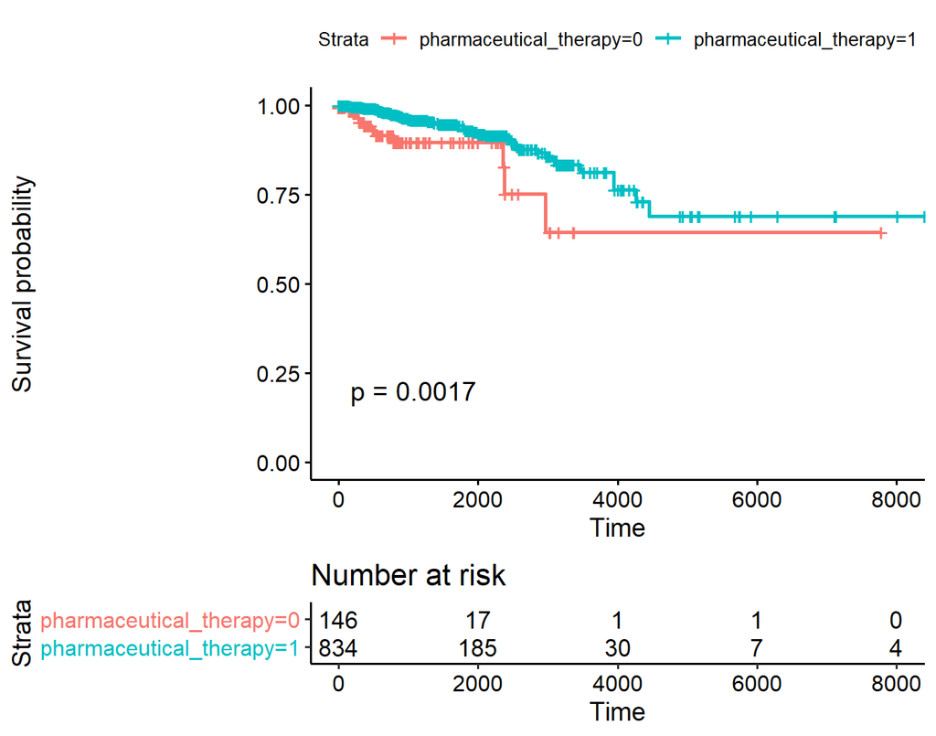

```r
fit = survfit(formula = Surv(time_fu,vital_status) ~ pharmaceutical_therapy, data = SData)
ggsurvplot(fit, data = SData, pval = TRUE, risk.table = TRUE, surv.median.line = "hv",tables.height = 0.25)
```

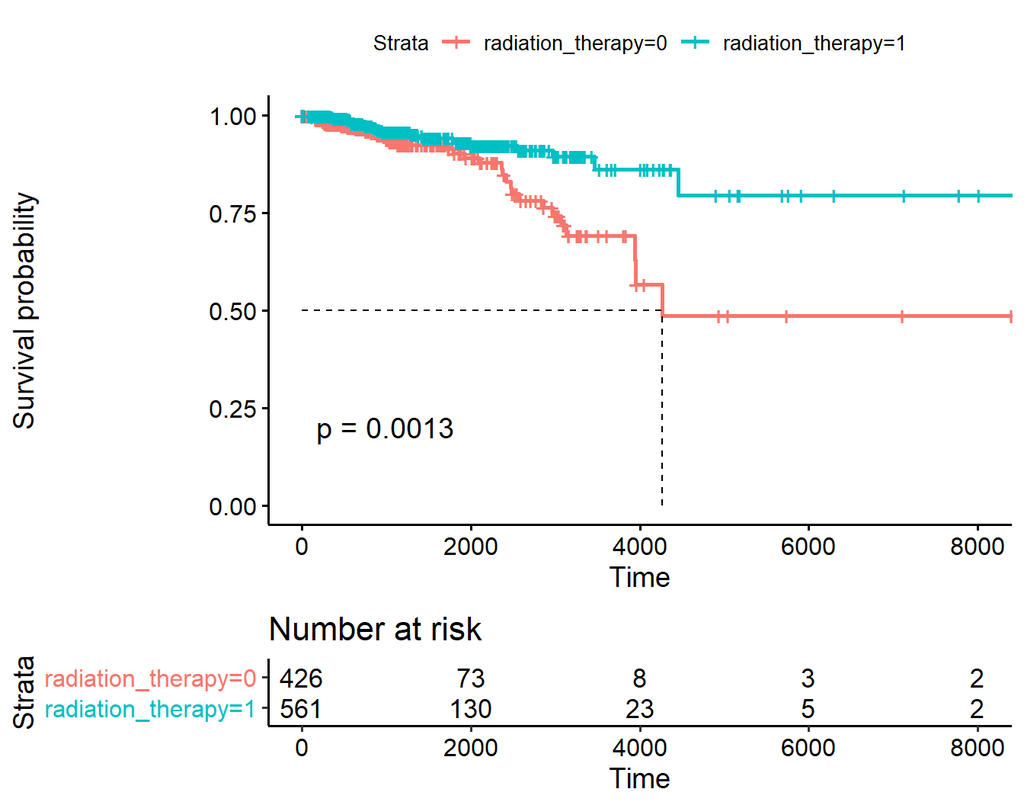

```r
fit = survfit(formula = Surv(time_fu,vital_status) ~ radiation_therapy, data = SData)
ggsurvplot(fit, data = SData, pval = TRUE, risk.table = TRUE, surv.median.line = "hv",tables.height = 0.25)
```

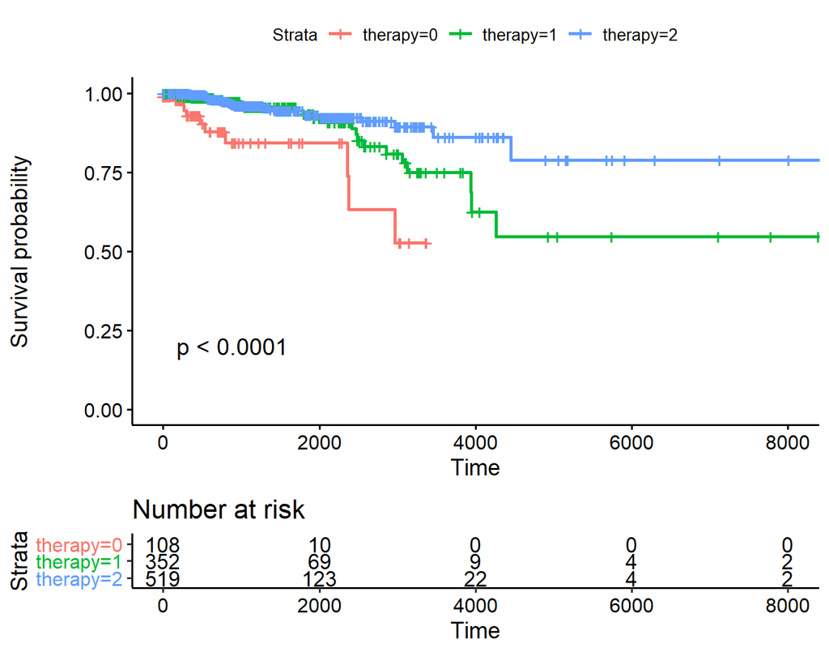

```r
fit = survfit(formula = Surv(time_fu,vital_status) ~ therapy, data = SData)
ggsurvplot(fit, data = SData, pval = TRUE, risk.table = TRUE, surv.median.line = "hv",tables.height = 0.25)
```

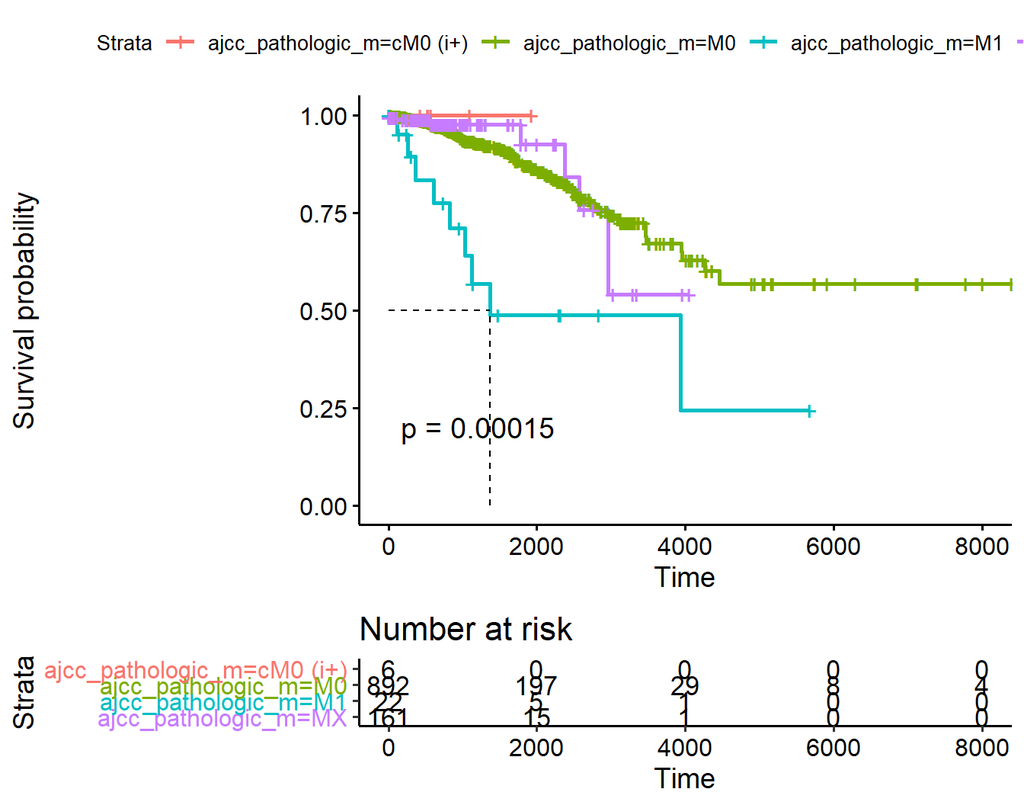

```r
fit = survfit(formula = Surv(time_fu,vital_status) ~ ajcc_pathologic_m, data = SData)
ggsurvplot(fit, data = SData, pval = TRUE, risk.table = TRUE, surv.median.line = "hv",tables.height = 0.25)
```

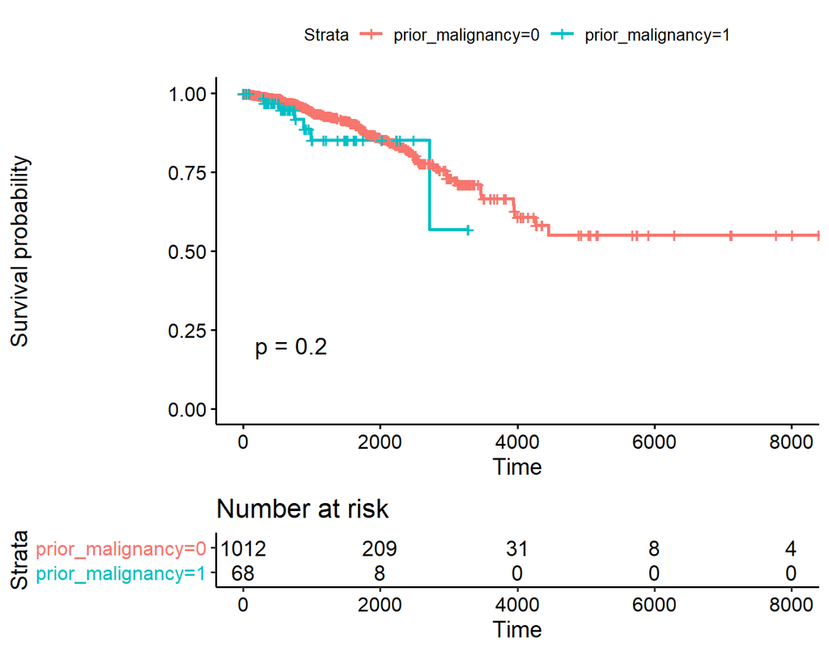

```r
fit = survfit(formula = Surv(time_fu,vital_status) ~ prior_malignancy, data = SData)
ggsurvplot(fit, data = SData, pval = TRUE, risk.table = TRUE, surv.median.line = "hv",tables.height = 0.25)
```

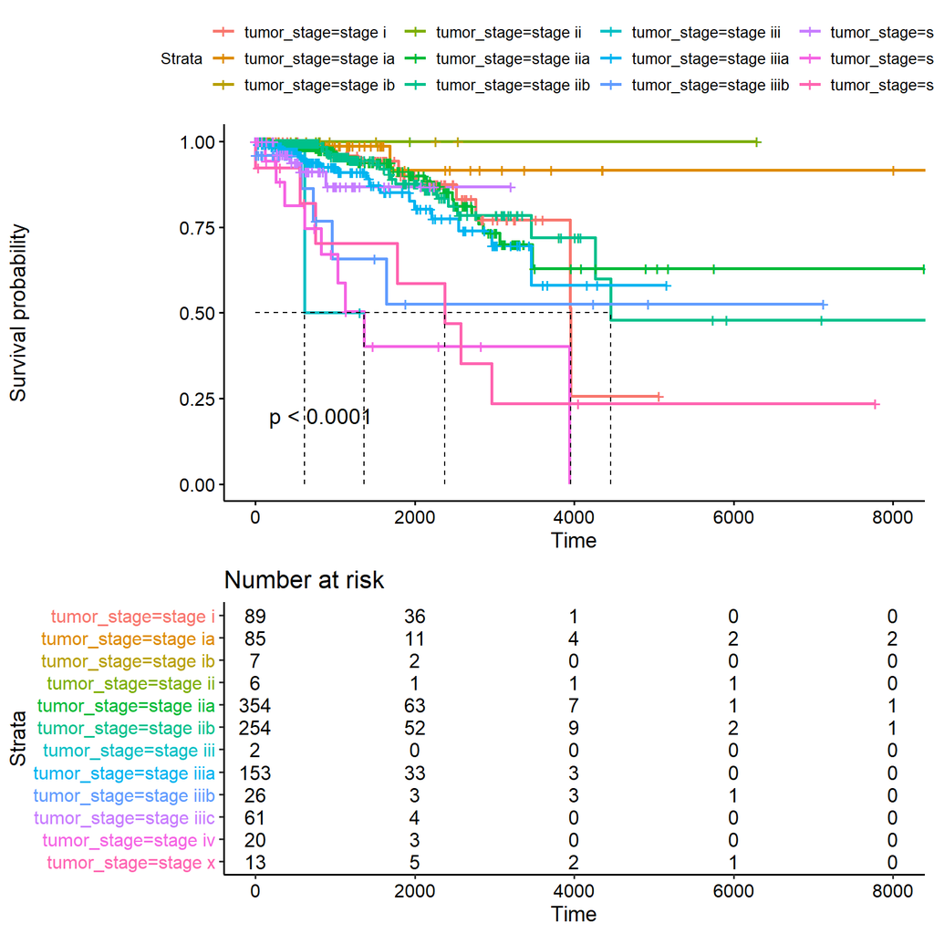

```r
fit = survfit(formula = Surv(time_fu,vital_status) ~ tumor_stage, data = SData)
ggsurvplot(fit, data = SData, pval = TRUE, risk.table = TRUE, surv.median.line = "hv",tables.height = 0.4)
```

### Modèles de Cox :

#### Modèle de Cox univarié

Si le test du log-rank permet de tester une différence significative de survie entre deux groupes par exemple, il n’est pas possible d’estimer l’étendu de l’impact de cette différence entre ces deux groupes.

Pour de quantifier cet impact, on fait appel au risque instantané h de décès de chacun des deux groupes (la probabilité selon laquelle un événement précis se produira à un instant fixé) et on cherche une fonction simple les reliant en se basant sur une hypothèse essentielle : *“la proportion des risques instantanés de décès est constante pendant toute la durée d’observation”*. Le modèle de Cox repose sur cette notion de risques proportionnels.

Considérons un modèle univarié avec la variable therapy :

```r
mod1=coxph(Surv(time_fu, vital_status) ~ therapy, data = SData)

mod1
```

```
## Call:
## coxph(formula = Surv(time_fu, vital_status) ~ therapy, data = SData)
##
##             coef exp(coef) se(coef)      z        p
## therapy1 -1.2170    0.2961   0.3682 -3.305 0.000949
## therapy2 -1.7086    0.1811   0.3693 -4.626 3.72e-06
##
## Likelihood ratio test=17.04  on 2 df, p=0.0001995
## n= 979, number of events= 59
##    (102 observations deleted due to missingness)
```

```r
coxph(Surv(time_fu, vital_status) ~ therapy, data = SData) %>%
  gtsummary::tbl_regression(exp = TRUE)
```

| **Characteristic** | **HR**<sup>1</sup> | **95% CI**<sup>1</sup> | **p-value** |
| --- | --- | --- | --- |
| therapy |  |  |  |
| 0 | — | — |  |
| 1 | 0.30 | 0.14, 0.61 | <0.001 |
| 2 | 0.18 | 0.09, 0.37 | <0.001 |

<sup>*1*</sup> HR = Hazard Ratio, CI = Confidence Interval

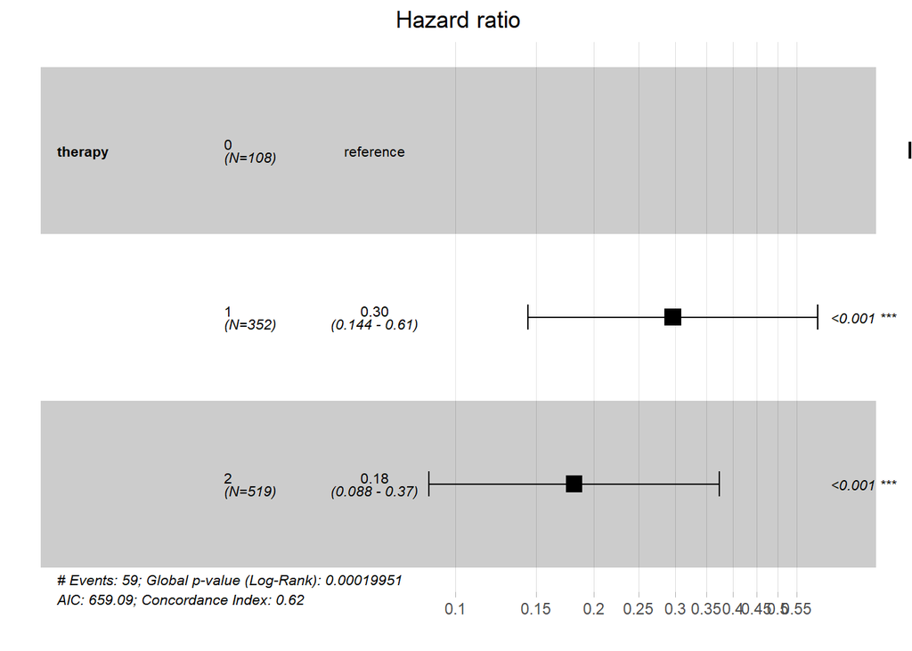

```r
ggforest(mod1)
```

Le risque proportionnel HR correspond à l’impact (en proportion) d’un groupe de traitement proportionnelement au groupe de référence sur le risque global h

HR < 1 indique un risque réduit. HR > 1 indique un risque augmenté.

L’effet des thérapies (therapie = 2) diminue le risque h de décès d’un facteur 0.18, soit un risque de décès dans le groupe sans thérapies qui est 1/0.18 = 5.6 fois supérieur à celui du groupe traitement+radiothrapie.

On pourrait considerer un autre modèle pour évaluer l’impact de l’age de diagnostique une variable continue sur la survie.

```r
coxph(Surv(time_fu, vital_status) ~ age_at_index, data = SData) %>%
  gtsummary::tbl_regression(exp = TRUE)
```

| **Characteristic** | **HR**<sup>1</sup> | **95% CI**<sup>1</sup> | **p-value** |
| --- | --- | --- | --- |
| age_at_index | 1.04 | 1.02, 1.05 | <0.001 |

<sup>*1*</sup> HR = Hazard Ratio, CI = Confidence Interval

Le test est significatif et il s’emblerait que l’augmentation de l’âge de diagnostique aurait quant à elle un impact negatif sur la survie (HR>0)

#### Modèle de Cox multivarié

Considerons maintenant un modèle multivariés en introduisant les variables qui nous semblent intressantes :

```r
mod2=coxph(Surv(time_fu, vital_status) ~
             age_at_index+
             tumor_stage+
             ajcc_pathologic_n+
             ajcc_pathologic_m+
             ajcc_pathologic_t+
             prior_malignancy+
             prior_treatment+
             radiation_therapy+
             pharmaceutical_therapy, data = SData)
mod2
```

```
## Call:
## coxph(formula = Surv(time_fu, vital_status) ~ age_at_index +
##     tumor_stage + ajcc_pathologic_n + ajcc_pathologic_m + ajcc_pathologic_t +
##     prior_malignancy + prior_treatment + radiation_therapy +
##     pharmaceutical_therapy, data = SData)
##
##                                  coef  exp(coef)   se(coef)      z        p
## age_at_index                3.084e-02  1.031e+00  1.011e-02  3.049 0.002295
## tumor_stagestage ia        -8.259e-01  4.378e-01  1.010e+00 -0.818 0.413299
## tumor_stagestage ib        -1.652e+01  6.669e-08  5.374e+03 -0.003 0.997547
## tumor_stagestage ii        -1.666e+01  5.813e-08  3.026e+03 -0.006 0.995607
## tumor_stagestage iia       -9.189e-04  9.991e-01  3.083e-01 -0.003 0.997621
## tumor_stagestage iib       -1.028e+00  3.578e-01  3.917e-01 -2.624 0.008701
## tumor_stagestage iii        3.707e+00  4.072e+01  1.017e+00  3.644 0.000269
## tumor_stagestage iiia       3.443e-01  1.411e+00  3.259e-01  1.056 0.290757
## tumor_stagestage iiib      -5.957e-01  5.512e-01  7.269e-01 -0.820 0.412490
## tumor_stagestage iiic       7.726e-01  2.165e+00  5.359e-01  1.442 0.149369
## tumor_stagestage iv         1.634e+01  1.253e+07  4.534e-01 36.051  < 2e-16
## tumor_stagestage x          2.334e+00  1.032e+01  4.094e-01  5.701 1.19e-08
## ajcc_pathologic_nN0 (i-)    1.308e+00  3.698e+00  3.668e-01  3.566 0.000363
## ajcc_pathologic_nN0 (i+)    1.527e+00  4.602e+00  7.215e-01  2.116 0.034360
## ajcc_pathologic_nN0 (mol+) -1.845e+01  9.680e-09  3.813e+05  0.000 0.999961
## ajcc_pathologic_nN1         1.171e+00  3.225e+00  5.202e-01  2.251 0.024406
## ajcc_pathologic_nN1a       -4.696e-01  6.252e-01  1.010e+00 -0.465 0.641996
## ajcc_pathologic_nN1b        3.651e+00  3.853e+01  3.493e-01 10.454  < 2e-16
## ajcc_pathologic_nN1c       -1.397e+01  8.579e-07  7.757e+03 -0.002 0.998563
## ajcc_pathologic_nN1mi       2.534e+00  1.260e+01  7.227e-01  3.506 0.000455
## ajcc_pathologic_nN2         1.226e+00  3.408e+00  5.967e-01  2.055 0.039890
## ajcc_pathologic_nN2a        2.681e+00  1.459e+01  4.363e-01  6.145 8.01e-10
## ajcc_pathologic_nN3         1.082e+00  2.950e+00  5.997e-01  1.804 0.071237
## ajcc_pathologic_nN3a        1.144e+00  3.139e+00  7.259e-01  1.576 0.115087
## ajcc_pathologic_nN3b        4.984e+00  1.460e+02  8.509e-01  5.857 4.71e-09
## ajcc_pathologic_nN3c        6.073e+00  4.341e+02  1.037e+00  5.856 4.74e-09
## ajcc_pathologic_nNX         2.873e+00  1.768e+01  4.101e-01  7.005 2.48e-12
## ajcc_pathologic_mM0         1.440e+01  1.793e+06  3.231e-01 44.566  < 2e-16
## ajcc_pathologic_mM1         0.000e+00  1.000e+00  4.534e-01  0.000 1.000000
## ajcc_pathologic_mMX         1.273e+01  3.394e+05  4.099e-01 31.068  < 2e-16
## ajcc_pathologic_tT1a        0.000e+00  1.000e+00  0.000e+00     NA       NA
## ajcc_pathologic_tT1b       -1.595e+01  1.178e-07  2.321e+03 -0.007 0.994516
## ajcc_pathologic_tT1c       -4.203e-01  6.569e-01  3.533e-01 -1.189 0.234273
## ajcc_pathologic_tT2         2.491e-01  1.283e+00  2.682e-01  0.929 0.352936
## ajcc_pathologic_tT2a       -2.037e+01  1.422e-09  3.813e+05  0.000 0.999957
## ajcc_pathologic_tT2b        0.000e+00  1.000e+00  0.000e+00     NA       NA
## ajcc_pathologic_tT3        -1.585e-01  8.534e-01  3.419e-01 -0.464 0.642822
## ajcc_pathologic_tT4         1.512e+00  4.537e+00  1.011e+00  1.495 0.134835
## ajcc_pathologic_tT4b        1.350e-01  1.145e+00  7.228e-01  0.187 0.851870
## ajcc_pathologic_tT4d        3.393e-01  1.404e+00  1.370e+00  0.248 0.804419
## ajcc_pathologic_tTX        -2.451e+00  8.617e-02  1.017e+00 -2.411 0.015906
## prior_malignancy1           8.444e-01  2.327e+00  4.804e-01  1.758 0.078764
## prior_treatment1            1.332e+00  3.788e+00  7.301e-01  1.824 0.068120
## radiation_therapy1         -1.067e+00  3.441e-01  2.684e-01 -3.974 7.06e-05
## pharmaceutical_therapy1    -9.792e-01  3.756e-01  3.350e-01 -2.923 0.003469
##
## Likelihood ratio test=145.2  on 45 df, p=1.757e-12
## n= 968, number of events= 58
##    (113 observations deleted due to missingness)
```

```r
mod2 %>% gtsummary::tbl_regression(exp = TRUE)
```

| **Characteristic** | **HR**<sup>1</sup> | **95% CI**<sup>1</sup> | **p-value** |
| --- | --- | --- | --- |
| age_at_index | 1.03 | 1.01, 1.05 | 0.002 |
| tumor_stage |  |  |  |
| stage i | — | — |  |
| stage ia | 0.44 | 0.06, 3.17 | 0.4 |
| stage ib | 0.00 | 0.00, Inf | >0.9 |
| stage ii | 0.00 | 0.00, Inf | >0.9 |
| stage iia | 1.00 | 0.55, 1.83 | >0.9 |
| stage iib | 0.36 | 0.17, 0.77 | 0.009 |
| stage iii | 40.7 | 5.54, 299 | <0.001 |
| stage iiia | 1.41 | 0.74, 2.67 | 0.3 |
| stage iiib | 0.55 | 0.13, 2.29 | 0.4 |
| stage iiic | 2.17 | 0.76, 6.19 | 0.15 |
| stage iv | 12,534,797 | 5,154,878, 30,480,087 | <0.001 |
| stage x | 10.3 | 4.63, 23.0 | <0.001 |
| ajcc_pathologic_n |  |  |  |
| N0 | — | — |  |
| N0 (i-) | 3.70 | 1.80, 7.59 | <0.001 |
| N0 (i+) | 4.60 | 1.12, 18.9 | 0.034 |
| N0 (mol+) | 0.00 | 0.00, Inf | >0.9 |
| N1 | 3.22 | 1.16, 8.94 | 0.024 |
| N1a | 0.63 | 0.09, 4.53 | 0.6 |
| N1b | 38.5 | 19.4, 76.4 | <0.001 |
| N1c | 0.00 | 0.00, Inf | >0.9 |
| N1mi | 12.6 | 3.06, 52.0 | <0.001 |
| N2 | 3.41 | 1.06, 11.0 | 0.040 |
| N2a | 14.6 | 6.21, 34.3 | <0.001 |
| N3 | 2.95 | 0.91, 9.56 | 0.071 |
| N3a | 3.14 | 0.76, 13.0 | 0.12 |
| N3b | 146 | 27.6, 774 | <0.001 |
| N3c | 434 | 56.9, 3,314 | <0.001 |
| NX | 17.7 | 7.92, 39.5 | <0.001 |
| ajcc_pathologic_m |  |  |  |
| cM0 (i+) | — | — |  |
| M0 | 1,793,084 | 951,866, 3,377,735 | <0.001 |
| M1 | 1.00 | 0.41, 2.43 | >0.9 |
| MX | 339,362 | 151,971, 757,821 | <0.001 |
| ajcc_pathologic_t |  |  |  |
| T1 | — | — |  |
| T1a | 1.00 | 1.00, 1.00 |  |
| T1b | 0.00 | 0.00, Inf | >0.9 |
| T1c | 0.66 | 0.33, 1.31 | 0.2 |
| T2 | 1.28 | 0.76, 2.17 | 0.4 |
| T2a | 0.00 | 0.00, Inf | >0.9 |
| T2b | 1.00 | 1.00, 1.00 |  |
| T3 | 0.85 | 0.44, 1.67 | 0.6 |
| T4 | 4.54 | 0.63, 32.9 | 0.13 |
| T4b | 1.14 | 0.28, 4.72 | 0.9 |
| T4d | 1.40 | 0.10, 20.6 | 0.8 |
| TX | 0.09 | 0.01, 0.63 | 0.016 |
| prior_malignancy |  |  |  |
| 0 | — | — |  |
| 1 | 2.33 | 0.91, 5.96 | 0.079 |
| prior_treatment |  |  |  |
| 0 | — | — |  |
| 1 | 3.79 | 0.91, 15.8 | 0.068 |
| radiation_therapy |  |  |  |
| 0 | — | — |  |
| 1 | 0.34 | 0.20, 0.58 | <0.001 |
| pharmaceutical_therapy |  |  |  |
| 0 | — | — |  |
| 1 | 0.38 | 0.19, 0.72 | 0.003 |

<sup>*1*</sup> HR = Hazard Ratio, CI = Confidence Interval

**Selection de variables :**

Voyons si nous pouvons, avec la fonction step, améliorer notre modèle par minimisation de l’AIC.

Pour procéder, on doit supprimer les données manquantes pour que la fonction step() fonctionne :

```r
#On va d'abord selectionner les variables de notre modèle dans un sous table afin d'eliminer les données manquantes :

tmp=na.omit(SData[,c("vital_status","time_fu","age_at_index", "ajcc_pathologic_n", "ajcc_pathologic_m", "ajcc_pathologic_t", "prior_malignancy", "prior_treatment", "radiation_therapy",  "pharmaceutical_therapy", "tumor_stage","therapy")])

m2=coxph(Surv(time_fu, vital_status) ~
             age_at_index+
             tumor_stage+
             ajcc_pathologic_n+
             ajcc_pathologic_m+
             ajcc_pathologic_t+
             prior_malignancy+
             prior_treatment+
             radiation_therapy+
             pharmaceutical_therapy, data = tmp)


stp=step(m2, trace = 1)
```

[output not shown]

Revenons au jeu de donnes initial :

```r
AIC(coxph(formula = Surv(time_fu, vital_status) ~ age_at_index +
    tumor_stage + ajcc_pathologic_n + ajcc_pathologic_m + prior_malignancy +
    radiation_therapy, data = SData))
```

```
## [1] 639.8657
```

```r
AIC(coxph(formula = Surv(time_fu, vital_status) ~ age_at_index +
    tumor_stage + ajcc_pathologic_n + ajcc_pathologic_m + prior_malignancy +
    therapy, data = SData))
```

```
## [1] 586.4029
```

Ainsi le modèle définitif est le suivant :

```r
mod2=coxph(formula = Surv(time_fu, vital_status) ~ age_at_index +
    tumor_stage + ajcc_pathologic_n + ajcc_pathologic_m + prior_malignancy +
    therapy, data = SData)

mod2 %>% gtsummary::tbl_regression(exp = TRUE)
```

| **Characteristic** | **HR**<sup>1</sup> | **95% CI**<sup>1</sup> | **p-value** |
| --- | --- | --- | --- |
| age_at_index | 1.03 | 1.00, 1.05 | 0.017 |
| tumor_stage |  |  |  |
| stage i | — | — |  |
| stage ia | 0.56 | 0.06, 5.69 | 0.6 |
| stage ib | 0.00 | 0.00, Inf | >0.9 |
| stage ii | 0.00 | 0.00, Inf | >0.9 |
| stage iia | 2.43 | 0.66, 8.96 | 0.2 |
| stage iib | 0.94 | 0.17, 5.09 | >0.9 |
| stage iii | 49.0 | 2.83, 851 | 0.008 |
| stage iiia | 2.18 | 0.36, 13.1 | 0.4 |
| stage iiib | 1.82 | 0.21, 15.5 | 0.6 |
| stage iiic | 3.74 | 0.29, 48.6 | 0.3 |
| stage iv | 25,714,258 | 2,577,998, 256,487,065 | <0.001 |
| stage x | 4.55 | 0.65, 32.0 | 0.13 |
| ajcc_pathologic_n |  |  |  |
| N0 | — | — |  |
| N0 (i-) | 3.16 | 0.98, 10.2 | 0.055 |
| N0 (i+) | 4.95 | 0.91, 27.0 | 0.065 |
| N0 (mol+) |  |  |  |
| N1 | 3.24 | 0.78, 13.5 | 0.11 |
| N1a | 0.74 | 0.08, 7.16 | 0.8 |
| N1b | 36.0 | 8.91, 145 | <0.001 |
| N1c | 0.00 | 0.00, Inf | >0.9 |
| N1mi | 9.14 | 1.56, 53.6 | 0.014 |
| N2 | 4.13 | 0.63, 27.2 | 0.14 |
| N2a | 16.2 | 3.07, 85.7 | 0.001 |
| N3 | 3.19 | 0.41, 24.9 | 0.3 |
| N3a | 4.28 | 0.42, 44.0 | 0.2 |
| N3b | 191 | 13.3, 2,740 | <0.001 |
| N3c | 488 | 20.5, 11,624 | <0.001 |
| NX | 26.0 | 3.96, 171 | <0.001 |
| ajcc_pathologic_m |  |  |  |
| cM0 (i+) | — | — |  |
| M0 | 2,116,001 | 522,031, 8,576,990 | <0.001 |
| M1 |  |  |  |
| MX |  |  |  |
| prior_malignancy |  |  |  |
| 0 | — | — |  |
| 1 | 3.63 | 1.31, 10.1 | 0.013 |
| therapy |  |  |  |
| 0 | — | — |  |
| 1 | 0.30 | 0.12, 0.71 | 0.007 |
| 2 | 0.12 | 0.05, 0.33 | <0.001 |

<sup>*1*</sup> HR = Hazard Ratio, CI = Confidence Interval

On peut aussi comparer les deux modèle univarié et multivarié en réalisant un test de Fisher pour modèles emboités avec la fonction anova()

```r
m1=coxph(formula = Surv(time_fu, vital_status) ~ therapy, data = tmp)
m2=coxph(formula = Surv(time_fu, vital_status) ~ age_at_index +
    tumor_stage + ajcc_pathologic_n + ajcc_pathologic_m + prior_malignancy +
    therapy, data = tmp)


anova(m1, m2, test="Chisq")
```

```
## Analysis of Deviance Table
##  Cox model: response is  Surv(time_fu, vital_status)
##  Model 1: ~ therapy
##  Model 2: ~ age_at_index + tumor_stage + ajcc_pathologic_n + ajcc_pathologic_m + prior_malignancy + therapy
##    loglik Chisq Df P(>|Chi|)
## 1 -322.75
## 2 -263.20 119.1 28 3.327e-13 ***
## ---
## Signif. codes:  0 '***' 0.001 '**' 0.01 '*' 0.05 '.' 0.1 ' ' 1
```

Il est significatif et en faveur du modèle multivarié

Testons l’hypothèse de risques proportionnels :

```r
cox.zph(m1)
```

```
##         chisq df    p
## therapy  2.24  2 0.33
## GLOBAL   2.24  2 0.33
```

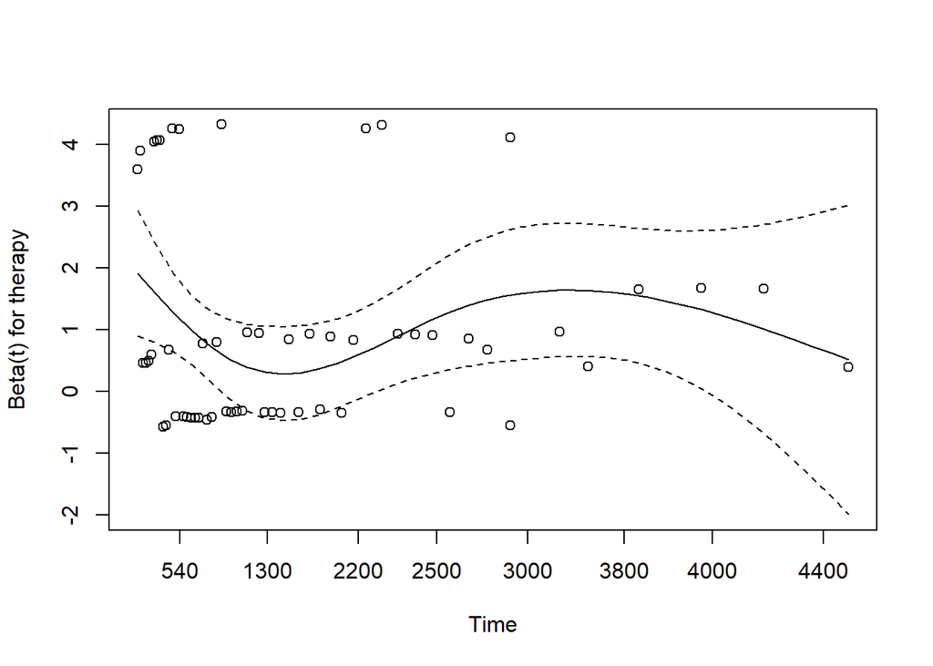

```r
plot(cox.zph(m1))
```

```r
cox.zph(m2)
```

```
##                      chisq df    p
## age_at_index       0.05602  1 0.81
## tumor_stage        8.87553 11 0.63
## ajcc_pathologic_n 11.79543 14 0.62
## ajcc_pathologic_m  0.00843  1 0.93
## prior_malignancy   0.49792  1 0.48
## therapy            1.11111  2 0.57
## GLOBAL            27.50825 30 0.60
```

Pour le premier modèle (univarié), le test est non significatif, on peut donc penser que l’hypothèse de proportionnalité des risques est repectée.

Pour le second modèle (multivarié), le test est non significatif, on peut penser que l’hypothèse de proportionnalité des risques est repectée aussi dans ce cas.

Les courbes de survies associées à nos deux modèles (univarié et multivarié) :

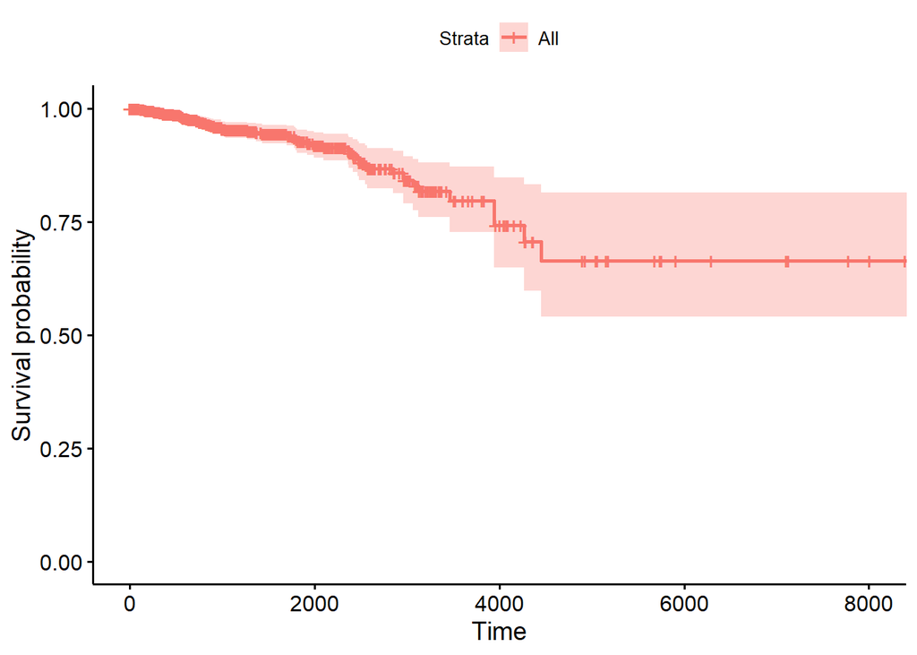

```r
ggsurvplot(survfit(mod1), data = SData, pval = TRUE,  surv.median.line = "hv")
```

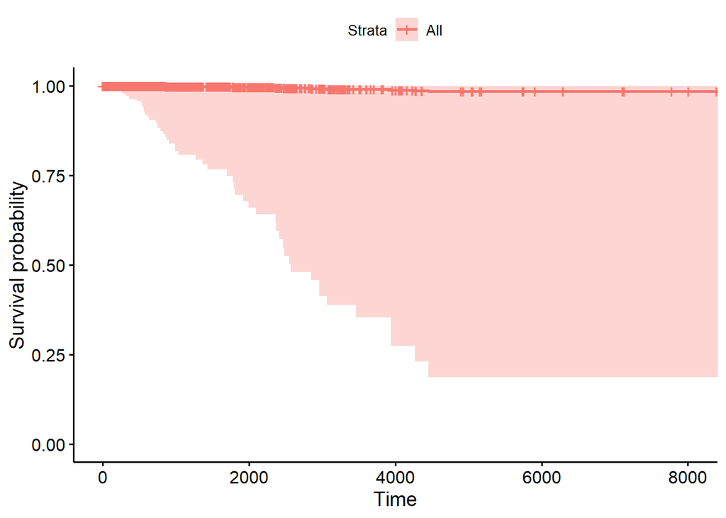

```r
ggsurvplot(survfit(mod2), data = SData, pval = TRUE,  surv.median.line = "hv")
```

**Prediction :**

```r
SD_train=SData[1:1000,c("vital_status","time_fu","age_at_index", "ajcc_pathologic_n", "ajcc_pathologic_m", "ajcc_pathologic_t", "prior_malignancy", "prior_treatment", "radiation_therapy",  "pharmaceutical_therapy", "tumor_stage","therapy")]

SD_test=SData[1001:1081,c("age_at_index", "ajcc_pathologic_n", "ajcc_pathologic_m", "ajcc_pathologic_t", "prior_malignancy", "prior_treatment", "radiation_therapy",  "pharmaceutical_therapy", "tumor_stage","therapy")]
```

```r
mod2_train=coxph(formula = Surv(time_fu, vital_status) ~ age_at_index +
    tumor_stage + ajcc_pathologic_n + ajcc_pathologic_m + prior_malignancy +
    therapy, data = SD_train)
```

Prenons 5 individus :

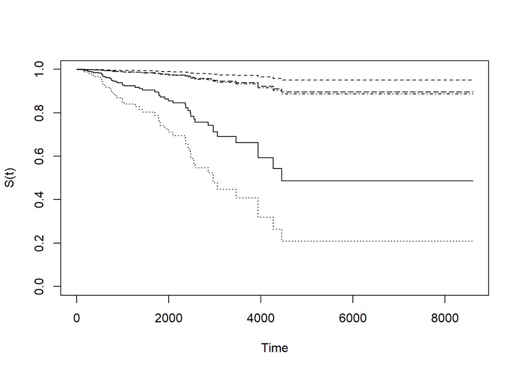

```r
t_mod2=survfit(mod2_train, newdata = SD_test[1:5,])

plot(t_mod2, lty =c(1:5), xlab = "Time", ylab = "S(t)")
```

```r
t_mod2
```

```
## Call: survfit(formula = mod2_train, newdata = SD_test[1:5, ])
##
##        n events median 0.95LCL 0.95UCL
## 1002 897     54   4456    3461      NA
## 1003 897     54     NA      NA      NA
## 1004 897     54   2965    1993      NA
## 1005 897     54     NA      NA      NA
## 1006 897     54     NA      NA      NA
```

```r
summary(t_mod2)
```

```
## Call: survfit(formula = mod2_train, newdata = SD_test[1:5, ])
##
##  time n.risk n.event survival1 survival2 survival3 survival4 survival5
##     0    897       1     0.999     1.000     0.999     1.000     1.000
##   116    850       1     0.999     1.000     0.997     1.000     1.000
##   158    844       1     0.997     1.000     0.994     1.000     1.000
##   160    843       1     0.996     1.000     0.991     0.999     0.999
##   172    837       1     0.995     1.000     0.989     0.999     0.999
##   239    818       1     0.993     1.000     0.986     0.999     0.999
##   255    812       1     0.992     0.999     0.982     0.999     0.999
##   266    810       1     0.990     0.999     0.979     0.998     0.999
##   322    786       1     0.989     0.999     0.975     0.998     0.998
##   362    763       1     0.987     0.999     0.971     0.998     0.998
##   365    760       1     0.985     0.999     0.967     0.997     0.998
##   468    658       1     0.983     0.999     0.962     0.997     0.997
```

[output cut: 40 more lines]

```r
predict(mod2_train, type="risk", newdata=SD_test[1:5,], cause=1)
```

```
##      1002      1003      1004      1005      1006
## 17.865862  1.241715 38.947684  2.994982  2.734251
```

Nous avons ainsi les risques estimés par notre modèle pour les 5 individus.